# FY2022 Analysis - Methodology for Fiscal Futures

Alea Wilbur

November 2022

```r
library(tidyverse)
library(haven)
library(formatR)
library(lubridate)
library(smooth)
library(forecast)
library(scales)
library(kableExtra)
library(ggplot2)
library(readxl)
library(tidyverse)
library(data.table)
library(quantmod)
library(geofacet)
library(janitor)


knitr::opts_chunk$set(echo = TRUE, warning = FALSE, message = FALSE, cache = TRUE)
```

# Data Creation and Cleaning

Code below reads in the csv files created in chunks above (allrevfiles.csv and allrexpfiles.csv). These files contain all years of data combined into one file BEFORE any recoding is done. Do not use this file for summing categories because it is just an inbetween step before recoding revenue and expenditure categories.

```r
# combined in past chunks called create-rev-csv and create-exp-csv

allrevfiles22 <- read_csv("allrevfiles22.csv") #combined but not recoded
allexpfiles22 <- read_csv("allexpfiles22.csv") #combined but not recoded
```

New or reused funds revenue file recoding:

```r
# if first character is a 0, replace with a 9 if its purpose has changed

rev_1998_2022 <- allrevfiles22 %>%
      mutate(fund = ifelse(fy < 2002 & fund %in% c("0730", "0241", "0350", "0367", "0381", "0382", "0526", "0603", "0734", "0913", "0379"), str_replace(fund, "0","9"), fund)) %>%

  mutate(fund = ifelse(fy < 2008 & fund %in% c("0027", "0033", "0037", "0058", "0062", "0066", "0075", "0083", "0116", "0119", "0120", "0122", "0148", "0149", "0157", "0158", "0166", "0194", "0201", "0209", "0211", "0217", "0223", "0231", "0234", "0253", "0320", "0503", "0505", "0512", "0516", "0531", "0532", "0533", "0547", "0563", "0579", "0591", "0606", "0616", "0624", "0659", "0662", "0665", "0676", "0710",
"0068", "0076", "0115", "0119", "0168", "0182", "0199", "0241", "0307", "0506", "0509", "0513"), str_replace(fund, "0","9"), fund)) %>%

  mutate(fund = ifelse(fy < 2016 & fund %in% c("0263", "0399", "0409"), str_replace(fund, "0","9"), fund)) %>%

  mutate(fund =  ifelse(fy < 2017 & fund == "0364", str_replace(fund, "0","9"), fund)) %>%

  mutate(fund =  ifelse(fy < 2018 & fund %in% c("0818", "0767", "0671", "0593", "0578"), str_replace(fund, "0","9"), fund)) %>%

  mutate(fund = ifelse(fy>1999 & fy < 2018 & fund == "0231", "10231", fund) ) %>%

  mutate(fund = ifelse(fy < 2019 & fund %in% c("0161", "0489", "0500", "0612", "0893", "0766"), str_replace(fund, "0","9"), fund)) %>%

  mutate(fund =  ifelse(fy < 2020 & fund %in% c("0254", "0304", "0324", "0610", "0887", "0908", "0939", "0968"), str_replace(fund, "0","9"), fund)) %>%

  mutate(fund =  ifelse(fy < 2021 & fund %in% c("0255", "0325", "0348", "0967", "0972"), str_replace(fund, "0","9"), fund) ) %>%

   #2022 changes
  mutate(fund = ifelse(fy < 2022 & fund %in% c("0110","0165","0351", "0392", "0393", "0422", "0544", "0628", "0634",  "0656", "0672", "0683", "0723", "0742", "0743"), str_replace(fund, "0","9"), as.character(fund))) %>%  # replaces first 0 it finds with a 9
  mutate(fund = ifelse(fy < 2022 & fund == "0367", "10367", as.character(fund)) # fund reused for 3rd time
)
```

Expenditure recoding:

```r
# if first character is a 0, replace with a 9

exp_1998_2022 <- allexpfiles22 %>%
      mutate(fund = ifelse(fy < 2002 & fund %in% c("0730", "0241", "0350", "0367", "0381", "0382", "0526", "0603", "0734", "0913", "0379"), str_replace(fund, "0","9"), fund)) %>%

  mutate(fund = ifelse(fy < 2008 & fund %in% c("0027", "0033", "0037", "0058", "0062", "0066", "0075", "0083", "0116", "0119", "0120", "0122", "0148", "0149", "0157", "0158", "0166", "0194", "0201", "0209", "0211", "0217", "0223", "0231", "0234", "0253", "0320", "0503", "0505", "0512", "0516", "0531", "0532", "0533", "0547", "0563", "0579", "0591", "0606", "0616", "0624", "0659", "0662", "0665", "0676", "0710",
"0068", "0076", "0115", "0119", "0168", "0182", "0199", "0241", "0307", "0506", "0509", "0513"), str_replace(fund, "0","9"), fund)) %>%

  mutate(fund = ifelse(fy < 2016 & fund %in% c("0263", "0399", "0409"), str_replace(fund, "0","9"), fund)) %>%

  mutate(fund =  ifelse(fy < 2017 & fund == "0364", str_replace(fund, "0","9"), fund)) %>%

  mutate(fund =  ifelse(fy < 2018 & fund %in% c("0818", "0767", "0671", "0593", "0578"), str_replace(fund, "0","9"), fund)) %>%
  mutate(fund = ifelse(fy>1999 & fy < 2018 & fund == "0231", "10231", fund) ) %>%

  mutate(fund = ifelse(fy < 2019 & fund %in% c("0161", "0489", "0500", "0612", "0893", "0766"), str_replace(fund, "0","9"), fund)) %>%

  mutate(fund =  ifelse(fy < 2020 & fund %in% c("0254", "0304", "0324", "0610", "0887", "0908", "0939", "0968"), str_replace(fund, "0","9"), fund)) %>%

  mutate(fund =  ifelse(fy < 2021 & fund %in% c("0255", "0325", "0348", "0967", "0972"), str_replace(fund, "0","9"), fund))  %>%

  #2022 changes
  mutate(fund = ifelse(fy < 2022 & fund %in% c("0110","0165","0351", "0392", "0393", "0422", "0544", "0628", "0634",  "0656", "0672", "0683","0723", "0742", "0743"), str_replace(fund, "0","9"), as.character(fund))) %>%  # replaces first 0 it finds with a 9
  mutate(fund = ifelse(fy < 2022 & fund == "0367", "10367", as.character(fund)) # fund reused for 3rd time
  )
```

```r
funds_ab_in_2022 = readxl::read_excel("C:/Users/aleaw/OneDrive/Documents/PhD Fall 2021 - Spring 2022/Merriman RA/Fiscal Futures FY2022/Replication-Files/funds_ab_in_2022.xlsx")


exp_temp <- exp_1998_2022 %>%
  arrange(fund, fy) %>%
  filter(expenditure != 0) %>%             # keeps everything that is not zero
# join  funds_ab_in_2021  to exp_temp
 left_join(funds_ab_in_2022, by = "fund")  # matches most recent fund number
```

Update Agencies: Early agencies replaced by successors

```r
# recodes old agency numbers to consistent agency number
exp_temp <- exp_temp %>%
  mutate(agency = case_when(
    (agency=="438"| agency=="475" |agency == "505") ~ "440",
    # financial institution &  professional regulation &
     # banks and real estate  --> coded as  financial and professional reg
    agency == "473" ~ "588", # nuclear safety moved into IEMA
    (agency =="531" | agency =="577") ~ "532", # coded as EPA
    (agency =="556" | agency == "538") ~ "406", # coded as agriculture
    agency == "560" ~ "592", # IL finance authority (fire trucks and agriculture stuff)to state fire marshal
    agency == "570" & fund == "0011" ~ "494",   # city of Chicago road fund to transportation
    TRUE ~ (as.character(agency))))
```

# Modify Expenditure File

### Tax refunds

Aggregate expenditures: Save tax refunds as negative revenue. Code refunds to match the rev_type codes (02=income taxes, 03 = corporate income taxes, 06=sales tax, 09=motor fuel tax, 21=inheritance tax, 24=insurance taxes and fees, 35 = all other tax refunds).

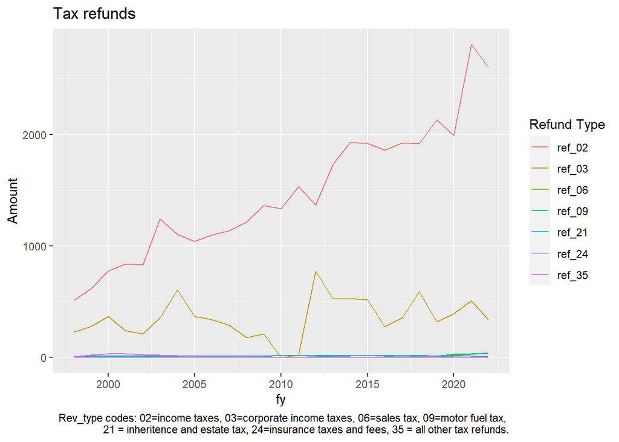

```r
## negative revenue becomes tax refunds

tax_refund_long <- exp_temp %>%           # fund != "0401" # removes State Trust Funds
  filter(fund != "0401" & (object=="9910"|object=="9921"|object=="9923"|object=="9925")) %>%
  # keeps these objects which represent revenue, insurance, treasurer,and financial and professional reg tax refunds
  mutate(refund = case_when(
    fund=="0278" & sequence == "00" ~ "02", # for income tax refund
    fund=="0278" & sequence == "01" ~ "03", # tax administration and enforcement and tax operations become corporate income tax refund
     fund == "0278" & sequence == "02" ~ "02",
    object=="9921" ~ "21",                # inheritance tax and estate tax refund appropriation
    object=="9923" ~ "09",                # motor fuel tax refunds
    obj_seq_type == "99250055" ~ "06",    # sales tax refund
    fund=="0378" & object=="9925" ~ "24", # insurance privilege tax refund
    fund=="0001" & object=="9925" ~ "35", # all other taxes
      T ~ "CHECK"))                       # if none of the items above apply to the observations, then code them as CHECK


exp_temp <- left_join(exp_temp, tax_refund_long) %>%
  mutate(refund = ifelse(is.na(refund),"not refund", as.character(refund)))

tax_refund <- tax_refund_long %>%
  group_by(refund, fy)%>%
  summarize(refund_amount = sum(expenditure, na.rm = TRUE)/1000000) %>%
  pivot_wider(names_from = refund, values_from = refund_amount, names_prefix = "ref_") %>%
  mutate_all(~replace_na(.,0)) %>%
  arrange(fy)

tax_refund %>% pivot_longer( ref_02:ref_35, names_to = "Refund Type", values_to = "Amount") %>%
  ggplot()+
  geom_line(aes(x=fy,y=Amount, group = `Refund Type`, color = `Refund Type`))+
  labs(title = "Refund Types", caption = "Refunds are excluded from Expenditure totals and instead subtracted from Revenue totals") +
  labs(title = "Tax refunds",
       caption = "Rev_type codes: 02=income taxes, 03=corporate income taxes, 06=sales tax, 09=motor fuel tax,
       21 = inheritence and estate tax, 24=insurance taxes and fees, 35 = all other tax refunds." )
```

```r
# remove the items we recoded in tax_refund_long
exp_temp <- exp_temp %>% filter(refund == "not refund")
```

`tax_refund` amounts are removed from expenditure totals and instead subtracted from revenue totals (since they were tax refunds).

### Pension Expenditures

> 300 million pension stabilization payment from fund 0319, object == 1900 for lump sums and other purposes. This is a type of pension contribution, right?

State payments to the following pension systems:

• Teachers Retirement System (TRS)  
- New POB bond in 2019: Accelerated Bond Fund paid benefits in advance as lump sum • State Employee Retirement System (SERS)  
• State University Retirement System (SURS)  
• Judges Retirement System (JRS)  
• General Assembly Retirement System (GARS)

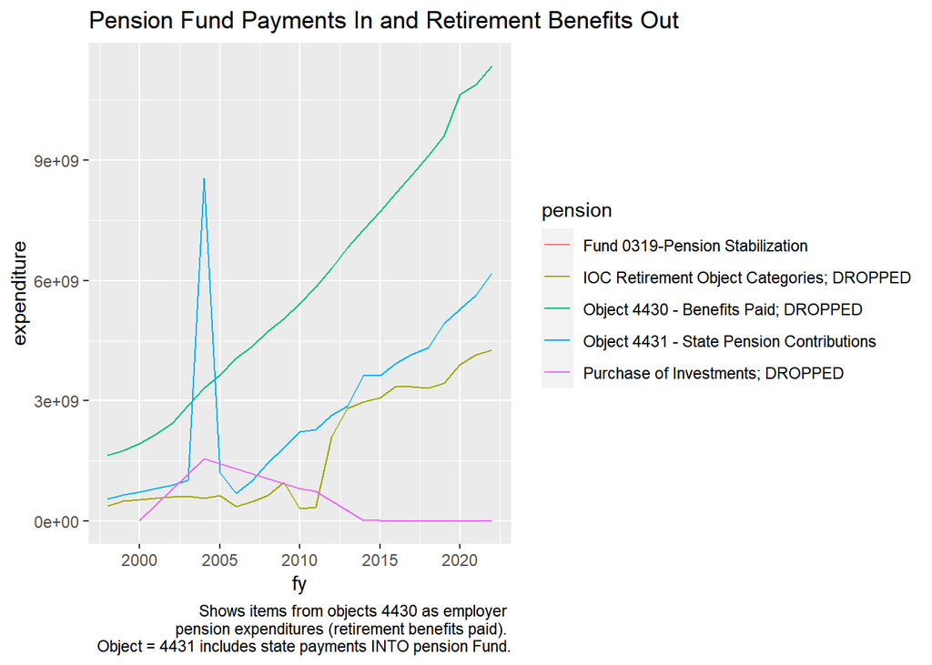

```r
# check what is being included in pensions

pension_check <- exp_temp %>%
  mutate(pension = case_when(
    (object=="4430") ~ "Object 4430 - Benefits Paid; DROPPED", # pensions, annuities, benefits
    (object=="4431") ~ "Object 4431 - State Pension Contributions", # 4431 = state payments into pension fund
        (obj_seq_type > "11590000" & obj_seq_type < "11660000")  ~ "IOC Retirement Object Categories; DROPPED",
    # objects 1159 to 1166 are all considered Retirement by Comptroller

            TRUE ~ "0")) %>%  # All other observations coded as 0 for non-pension items

  # recodes specific instances of code anomalies from past years:
  mutate(pension = case_when(
        # judges retirement "Purchase of investments" in 2010 and 2011
    (object=="1298" &
       #(fy==2010 | fy==2011) &
       (fund=="0477" | fund=="0479" | fund=="0481")) ~ "Purchase of Investments; DROPPED",

      # pension stabilization fund in 2022
  object == "1900" & fund == "0319" ~ "Fund 0319-Pension Stabilization",
    TRUE ~ as.character(pension)) ) %>%
  filter(pension != "0" )

pension_check %>% group_by(fy, pension) %>%
  summarize(expenditure = sum(expenditure, na.rm = TRUE)) %>%
  ggplot(aes(x=fy, y = expenditure, color = pension)) +
  geom_line() +
  labs (title = "Pension Fund Payments In and Retirement Benefits Out",
  caption = "Shows items from objects 4430 as employer
  pension expenditures (retirement benefits paid).
  Object = 4431 includes state payments INTO pension Fund.")
```

```r
pension_check2 <- exp_temp %>%
  mutate(pension = case_when(
     #   (object=="4431" | (object>"1159" & object<"1166") ) ~ 1,
       (object=="4431"  ) ~ 1, # 4431 = payments into pension fund
        (obj_seq_type > "11590000" & obj_seq_type < "11660000")  ~ 2,

    # objects 1159 to 1166 are all considered Retirement by Comptroller
    # object == 1167 also appears to be Other Retirement but isn't used yet
            TRUE ~ 0)) %>%

  mutate(pension = case_when(     # objects were weird for 2010 and 2011
   (object=="4431" & fund=="0473")  ~ 3, # teachers retirement system,
  #  obj_seq_type == "44310055" ~ 3, # teachers retirement system in 2010 and 2011.
   (object=="1298" &
      #(fy==2010 | fy==2011) &  # for the two weird years based on past code
      (fund=="0477" | fund=="0479" | fund=="0481")) ~ 3, # judges retirement
   # obj_seq_type == "12980055" ~ 3, # judge retirement contributions during 2010 and 2011
  object == "1900" & fund == "0319" ~ 5, # pension stabilization fund in 2022
    TRUE ~ pension)) %>%
  filter(pension > 0 )

#write_csv(pension_check, "pension_checkfy22v3.csv")

## taking care of Pension Obligation Bond proceeds

pension_check2 <- pension_check2 %>%
  # change object for 2010 and 2011, retirement expenditures were bond proceeds
  mutate(object = ifelse((pension == 3 & in_ff == "0"), "4431", as.character(object))) %>% # changes weird teacher & judge retirement system  pensions object to normal pension object 4431
  mutate(pension =  ifelse(pension == 1 & in_ff == "0", 2, pension)) %>% # coded as 2 if it was supposed to be excluded due to being bond proceeds ?
  mutate(in_ff = ifelse((pension ==2 | pension ==3), "1", as.character(in_ff)))


# create file with all pension items to find any mistakes
#pension_check %>% write_csv("all_pensions.csv")

table(pension_check2$pension)
```

```
##
##    1    2    3    5
##  226 8737   22    5
```

object==4431 + employee contributions rev should roughly equal object==4430 benefits being paid.

Modify exp_temp and move all state pension contributions to their own group (901):

```r
exp_temp <-  exp_temp %>%
  arrange(fund) %>%
  mutate(pension = case_when(

  # objects were weird for 2010 and 2011 for teacher and judge retirement system
     # (object=="4431" & fund=="0473") ~ 3, # teachers retirement system,
 # Was this: (object=="4431" & fund=="0473" &  (fy==2010 | fy==2011)) ~ 3, # teachers retirement system,
   (object=="4431") ~ 1, # 4431 = easy to find pension payments INTO fund

  (object>"1159" & object<"1166") & fund != "0183" & fund != "0193"   ~ 2,
   # objects 1159 to 1166 are all considered Retirement by Comptroller, OUT
  # object == 1167 also appears to be Other Retirement but isn't used yet

  (object=="1298" &  # Purchase of Investments
     (fy==2010 | fy==2011) &
     (fund=="0477" | fund=="0479" | fund=="0481")) ~ 3, #judges retirement OUT of fund


 fund == "0319" ~ 4, #pension stabilization fund IN?
                                        TRUE ~ 0) )

table(exp_temp$pension) # same number of total observations > 0 as pension_check
```

```
##
##      0      1      2      3      4
## 159004    228   8719      6      5
```

```r
# special accounting of pension obligation bond (POB)-funded contributions to JRS, SERS, GARS, TRS

exp_temp <- exp_temp %>%
  # change object for 2010 and 2011, retirement expenditures were bond proceeds
  mutate(object = ifelse((pension >0 & in_ff == "0"), "4431", object)) %>%
  # changes weird teacher & judge retirement system  pensions object to normal pension object 4431
  mutate(pension =  ifelse(pension >0 & in_ff == "0", 6, pension)) %>% # coded as 6 if it was supposed to be excluded.
  mutate(in_ff = ifelse(pension>0, "1", in_ff))

table(exp_temp$pension)
```

```
##
##      0      1      2      4      6
## 159004    226   8586      5    141
```

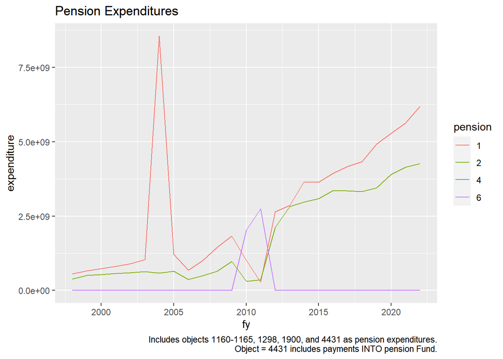

```r
# all other pensions objects  codes get agency code 901 for State Pension Contributions
exp_temp <- exp_temp %>%
  mutate(agency = ifelse(pension>0, "901", as.character(agency)),
         agency_name = ifelse(agency == "901", "State Pension Contributions", as.character(agency_name)))

exp_temp %>%
 filter(pension > 0) %>%
  mutate(pension = as.factor(pension)) %>%
  group_by(fy, pension) %>%
  summarize(expenditure = sum(expenditure, na.rm=TRUE)) %>%
  ggplot(aes(x=fy, y=expenditure, color = pension)) +
  geom_line() +
  labs (title = "Pension Expenditures",
  caption = "Includes objects 1160-1165, 1298, 1900, and 4431 as pension expenditures.
        Object = 4431 includes payments INTO pension Fund.")
```

### Drop Interfund transfers

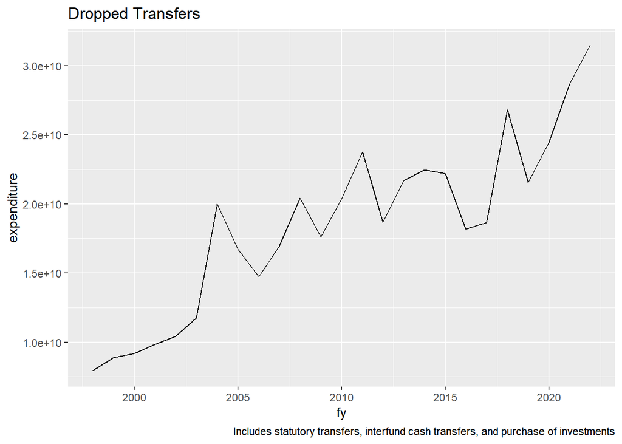

```r
transfers_drop <- exp_temp %>% filter(
  agency == "799" | # statutory transfers
           object == "1993" |  # interfund cash transfers
           object == "1298") # purchase of investments

#exp_temp <- anti_join(exp_temp, transfers_drop)

transfers_drop %>% group_by(fy) %>% summarize(expenditure = sum(expenditure)) %>% ggplot(aes(x=fy, y=expenditure)) + geom_line() + labs(title = "Dropped Transfers", caption = "Includes statutory transfers, interfund cash transfers, and purchase of investments")
```

### State employee healthcare costs

State Employee Health Care = Sum of expenditures for “health care coverage as elected by members per state employees group insurance act.” The payments are made from the Health Insurance Reserve Fund. We subtract the share that came from employee contributions. Employee contributions are not considered a revenue source or an expenditure in our analysis.

If observation is a group insurance contribution, then the expenditure amount is set to $0 (essentially dropped from analysis).

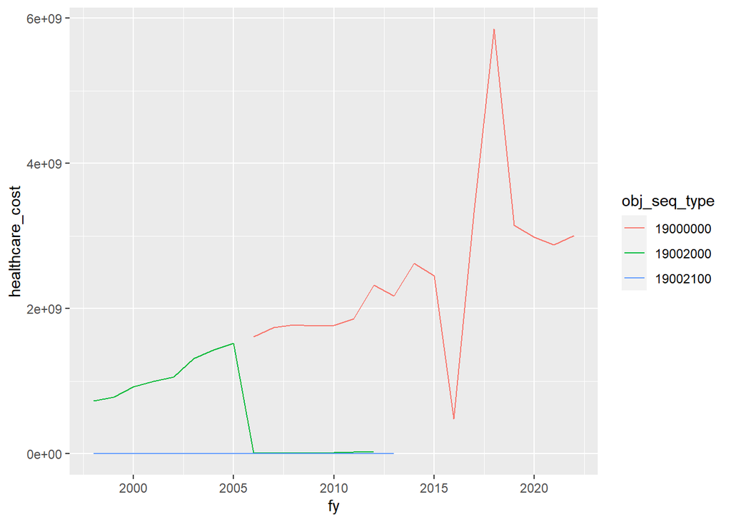

```r
#if observation is a group insurance contribution, then the expenditure amount is set to $0 (essentially dropped from analysis)
exp_temp <- exp_temp %>%
  mutate(eehc = ifelse(
    # group insurance contributions for 1998-2005 and 2013-present
   fund == "0001" & (object == "1180" | object =="1900") & agency == "416" & appr_org=="20", 0, 1) )%>%
  mutate(eehc = ifelse(
    # group insurance contributions for 2006-2012
    fund == "0001" & object == "1180" & agency == "478" & appr_org=="80", 0, eehc) )%>%
     # group insurance contributions from road fund
  # coded with 1900 for some reason??
    mutate(eehc = ifelse(
      fund == "0011" & object == "1900" & agency == "416" & appr_org=="20", 0, eehc) ) %>%

  mutate(expenditure = ifelse(eehc=="0", 0, expenditure)) %>%

  mutate(agency = case_when(   # turns specific items into State Employee Healthcare (agency=904)
      fund=="0907" & (agency=="416" & appr_org=="20") ~ "904",   # central management Bureau of benefits using health insurance reserve
      fund=="0907" & (agency=="478" & appr_org=="80") ~ "904",   # agency = 478: healthcare & family services using health insurance reserve - stopped using this in 2012
      TRUE ~ as.character(agency))) %>%
  mutate(agency_name = ifelse(agency == "904", "STATE EMPLOYEE HEALTHCARE", as.character(agency_name)),
         in_ff = ifelse( agency == "904", 1, in_ff),
         group = ifelse(agency == "904", "904", as.character(agency)))  # creates group variable

# Default group = agency number

healthcare_costs <- exp_temp %>% filter(group == "904")

healthcare_costs %>% group_by(fy,obj_seq_type) %>%
  summarise(healthcare_cost = sum(expenditure, na.rm = TRUE)) %>%
  ggplot() +geom_line(aes(x=fy, y=healthcare_cost, color = obj_seq_type))
```

```r
exp_temp <- anti_join(exp_temp, healthcare_costs) %>% mutate(expenditure = ifelse(object == "1180", 0, expenditure))

healthcare_costs_yearly <- healthcare_costs %>% group_by(fy, group) %>% summarise(healthcare_cost = sum(expenditure, na.rm = TRUE)/1000000) %>% select(-group)
```

This code chunk above for dealing with group insurance means that healthcare costs need to be added to expenditures after other group names are assigned. Then employee contributions/insurance premiums from the revenue side need to be subtracted from the total cost of employee healthcare for the net cost.

### Local Transfers

Separate transfers to local from parent agencies that come from DOR(492) or Transportation (494). Treats muni revenue transfers as expenditures, not negative revenue.

The share of certain taxes levied state-wide at a common rate and then transferred to local governments. (Purely local-option taxes levied by specific local governments with the state acting as collection agent are NOT included.)

The five corresponding revenue items are:

• Local share of Personal Income Tax  
• Local share of General Sales Tax  
• Personal Property Replacement Tax on Business Income  
• Personal Property Replacement Tax on Public Utilities  
• Local share of Motor Fuel Tax - Transportation Renewal Fund 0952

Notes - these don’t exit: - fund==“0627” & object==“4472”~ “976” # public transportation  
- fund==“0648” & object==“4472” ~ “976”,

```r
exp_temp <- exp_temp %>% mutate(
  agency = case_when(fund=="0515" & object=="4470" & type=="08" ~ "971", # income tax to local governments
                     fund=="0515" & object=="4491" & type=="08" & sequence=="00" ~ "971", # object is shared revenue payments
                     fund=="0802" & object=="4491" ~ "972", #pprt transfer
                     fund=="0515" & object=="4491" & type=="08" & sequence=="01" ~ "976", #gst to local
                     fund=="0627" & object=="4472"~ "976" , # public transportation fund but no observations exist
                     fund=="0648" & object=="4472" ~ "976", # downstate public transportation, but doesn't exist
                     fund=="0515" & object=="4470" & type=="00" ~ "976", # object 4470 is grants to local governments
                    object=="4491" & (fund=="0188"|fund=="0189") ~ "976",
                     fund=="0187" & object=="4470" ~ "976",
                     fund=="0186" & object=="4470" ~ "976",
                    object=="4491" & (fund=="0413"|fund=="0414"|fund=="0415")  ~ "975", #mft to local
                  fund == "0952"~ "975", # Added Sept 29 2022 AWM. Transportation Renewal MFT
                    TRUE ~ as.character(agency)),

  agency_name = case_when(agency == "971"~ "INCOME TAX 1/10 TO LOCAL",
                          agency == "972" ~ "PPRT TRANSFER TO LOCAL",
                          agency == "975" ~ "MFT TO LOCAL",
                          agency == "976" ~ "GST TO LOCAL",
                          TRUE~as.character(agency_name)),
  group = ifelse(agency>"970" & agency < "977", as.character(agency), as.character(group)))
```

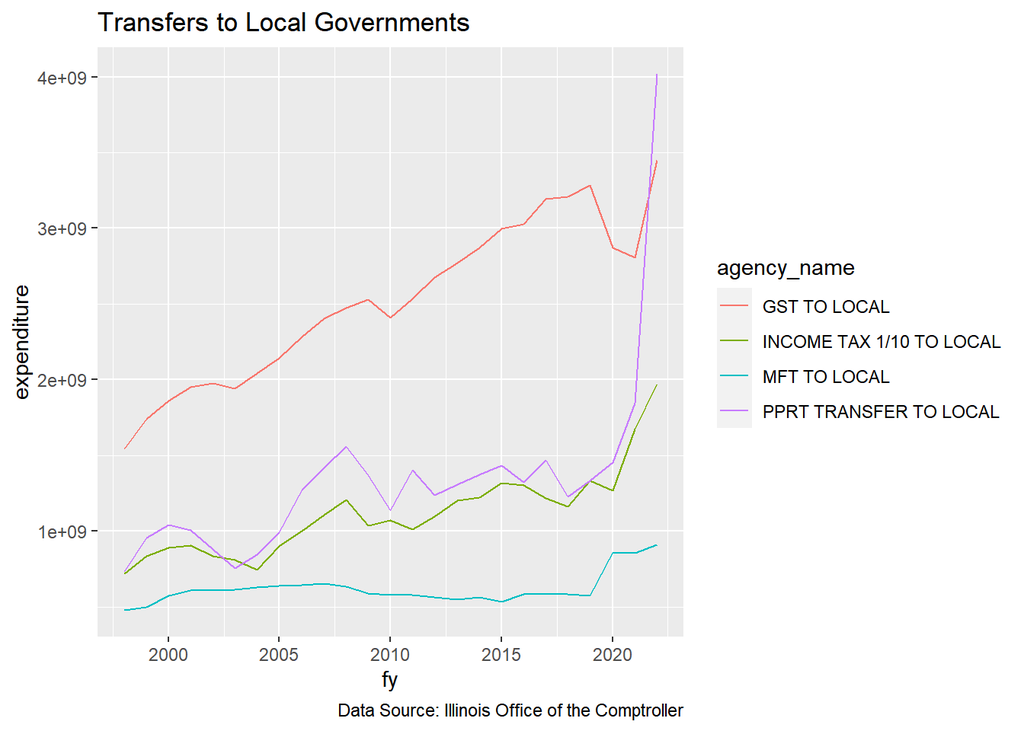

```r
transfers_long <- exp_temp %>%
  filter(group == "971" |group == "972" | group == "975" | group == "976")

transfers_long %>%
  group_by(agency_name, group, fy) %>%
  summarize(expenditure = sum(expenditure, na.rm=TRUE) )%>%
  ggplot() + geom_line(aes(x=fy, y = expenditure, color=agency_name)) + labs(title = "Transfers to Local Governments", caption = "Data Source: Illinois Office of the Comptroller")
```

```r
transfers <- transfers_long %>%
  group_by(fy, group ) %>%
  summarize(sum_expenditure = sum(expenditure)/1000000) %>%
  pivot_wider(names_from = "group", values_from = "sum_expenditure", names_prefix = "exp_" )

#exp_temp <- anti_join(exp_temp, transfers_long)


#dropped_inff_0 <- exp_temp %>% filter(in_ff == 0)

#exp_temp <- exp_temp %>% filter(in_ff == 1) # drops in_ff = 0 funds AFTER dealing with net-revenue above
```

### Debt Service

Debt Service expenditures include interest payment on both short-term and long-term debt. We do not include escrow or principal payments.

**Objects:**  
8813 interest **INCLUDE AS COST**  
8811 is for principle **EXCLUDE from aggregate debt expenditure**  
8841 is for escrow payments **EXCLUDE from aggregate debt expenditure**  
8800 is for capital projects (Build Illinois Bonds, Civic Center, Tollway **EXCLUDE tollway in debt cost** - Note: debt principle and interest are both included in capital projects because they are combined in the data observations; bond proceeds are not considered a revenue source

**Obj_seq_type:**  
- Exclude: Bond principle payments: obj_seq_type == 88110008  
- Exclude: Short term borrowing principle: obj_seq_type == 88110108  
- Include: General Obligation Bond Interest: obj_seq_type == 88130000 & 88130008  
- Include: Interest on short-term borrowing: 88130108  
- Exclude: Escrow payment == 88410008  
- Include: Build IL Bonds principal AND interest  
- Tollway is obj_seq_type == 88000055, filter out fund == 0455 to remove tollway  
- fund == 0455 is the IL State Toll Highway fund, items mostly for operations and maintenance

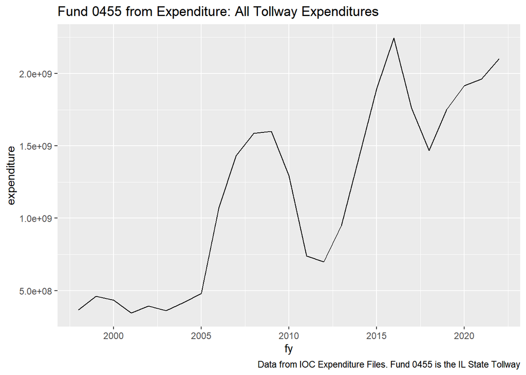

```r
tollway <- exp_temp %>% filter(fund == "0455") #all tollway expenditures
tollway_debt <- exp_temp %>%filter(object == "8800") # ALL Capital projects debt service



rev_temp <- inner_join(rev_1998_2022, funds_ab_in_2022, by = "fund") %>% arrange(source)

# look at Illinois tollway bond proceeds and debt service:
# rev_temp %>% filter(fund == "0455") # examine items in fund 0455
#exp_temp %>% filter(fund == "0455") %>% group_by(fy) %>% summarize(sum = sum(expenditure)) %>% arrange(-fy)

#rev_temp %>% filter(fund == "0455") %>% group_by(fy) %>% summarize(sum = sum(receipts)) %>% arrange(-fy)


exp_temp %>% filter(fund == "0455") %>% group_by(fy) %>% summarize(expenditure = sum(expenditure)) %>% ggplot() + geom_line(aes(x=fy, y=expenditure)) + labs(title = "Fund 0455 from Expenditure: All Tollway Expenditures", caption = "Data from IOC Expenditure Files. Fund 0455 is the IL State Tollway")
```

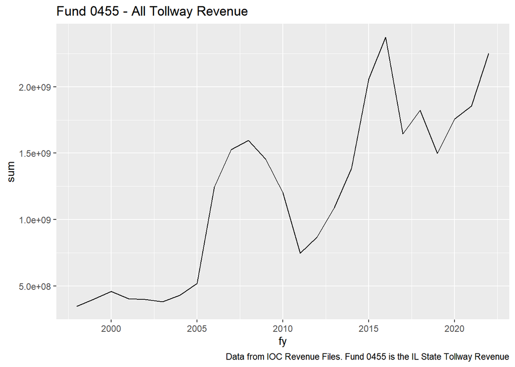

```r
# all tollway revenues, not just bond proceeds
rev_temp %>% filter(fund == "0455") %>% group_by(fy) %>% summarize(sum = sum(receipts))%>%  ggplot() + geom_line(aes(x=fy, y=sum)) + labs(title = "Fund 0455 - All Tollway Revenue", caption = "Data from IOC Revenue Files. Fund 0455 is the IL State Tollway Revenue")
```

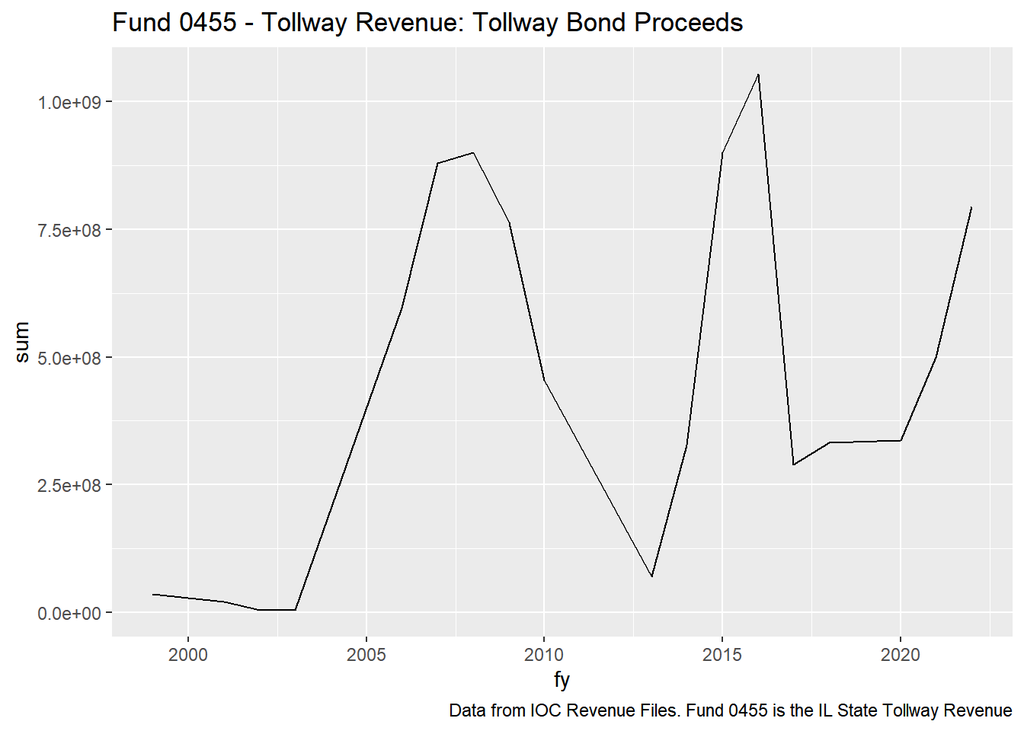

```r
# tollway bond proceeds
rev_temp %>% filter(fund == "0455" & source == "0571") %>% group_by(fy) %>% summarize(sum = sum(receipts))%>%
  ggplot() + geom_line(aes(x=fy, y=sum)) + labs(title = "Fund 0455 - Tollway Revenue: Tollway Bond Proceeds", caption = "Data from IOC Revenue Files. Fund 0455 is the IL State Tollway Revenue")
```

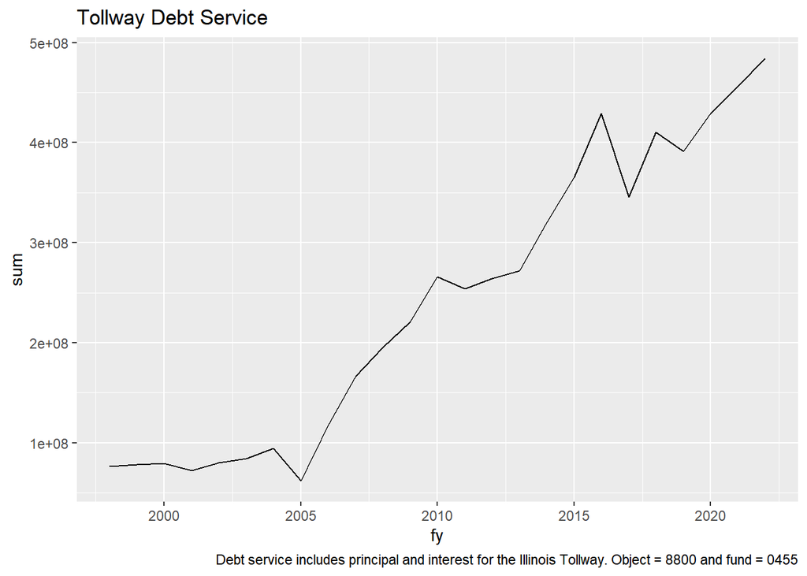

```r
#tollway debt principal and interest
exp_temp %>%filter(object == "8800" & fund == "0455") %>% group_by(fy) %>% summarize(sum=sum(expenditure)) %>%
  ggplot() + geom_line(aes(x=fy, y=sum)) + labs(title = "Tollway Debt Service", caption = "Debt service includes principal and interest for the Illinois Tollway. Object = 8800 and fund = 0455")
```

```r
# Tollway agency expenditures = SAME as filtering by fund == 0455
#tollway<-exp_temp %>% filter(agency == "557")
#exp_temp %>% filter(agency == "557") %>% group_by(fy) %>% summarize(sum = sum(expenditure)) %>% arrange(-fy)
```

```r
# GO bond principal and GO bond interest
GObond_debt <- exp_temp %>%
  filter(obj_seq_type == "88110008" |obj_seq_type == "88130000" | obj_seq_type == "88130008") %>%
  group_by(fy, obj_seq_type) %>%
  summarize(sum = sum(expenditure, na.rm=TRUE)) %>%
  pivot_wider(names_from = obj_seq_type, values_from = sum) %>%
  mutate(principal = `88110008`,
         interest = sum(`88130008`+`88130000`, na.rm = TRUE),
         ratio = (as.numeric(interest)/as.numeric(principal)))

GObond_debt %>% select(principal, interest, ratio) %>%
  mutate(across(principal:interest, ~format(., big.mark= ",", scientific = F)))
```

| fy | principal | interest | ratio |
| --- | --- | --- | --- |
| 1998 | 148,066,200 | 259,385,877 | 1.751824 |
| 1999 | 2,999,040 | 267,956,231 | 89.347335 |
| 2000 | 1,000,000 | 287,154,654 | 287.154654 |
| 2001 | 154,166,026 | 0 | 0.000000 |
| 2002 | 271,518,687 | 0 | 0.000000 |
| 2003 | 138,351,231 | 0 | 0.000000 |
| 2004 | 21,400,000 | 997,469,105 | 46.610706 |
| 2005 | 37,400,000 | 1,061,205,268 | 28.374472 |
| 2006 | 1,000,000,000 | 1,113,124,277 | 1.113124 |
| 2007 | 6,995,000 | 1,115,485,186 | 159.468933 |

[output cut: 15 more lines]

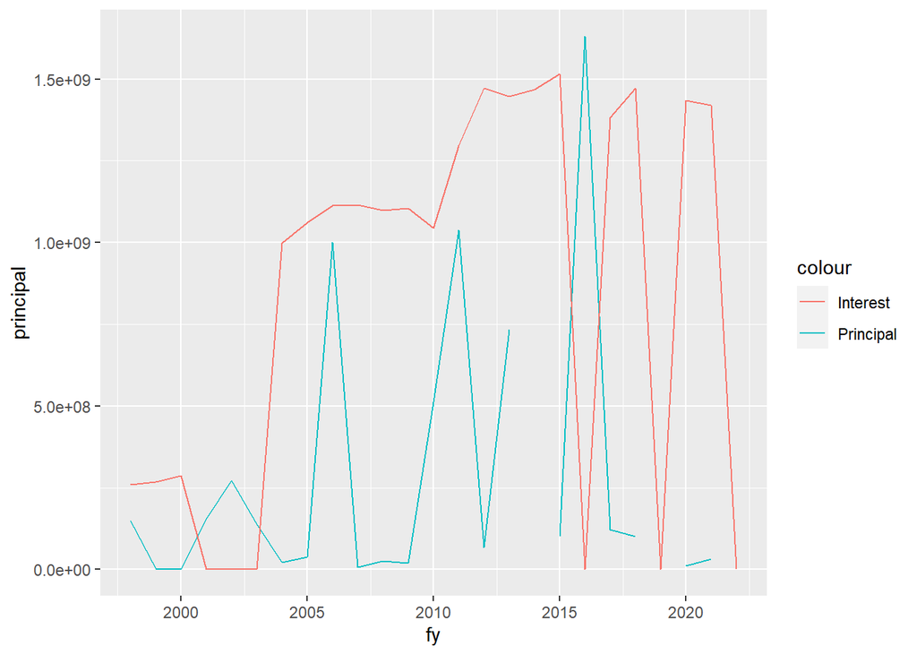

```r
GObond_debt %>% ggplot() +
  geom_line(aes(x=fy, y=principal, color = "Principal"))+
  geom_line(aes(x=fy, y=interest, color = "Interest"))
```

```r
# short term borrowing, first observation is in 2004?
short_debt <- exp_temp %>%
  filter(obj_seq_type == 88110108 |obj_seq_type == 88130108) %>%
  group_by(fy, obj_seq_type) %>%
  summarize(sum = sum(expenditure, na.rm=TRUE)) %>%
  pivot_wider(names_from = obj_seq_type, values_from = sum) %>%
  mutate(principal = `88110108`,
         interest = `88130108`,
         ratio = (as.numeric(interest)/as.numeric(principal)))

short_debt %>% select(principal, interest, ratio) %>%
  mutate(across(principal:interest, ~format(., big.mark= ",",  scientific = F)))
```

| fy | principal | interest | ratio |
| --- | --- | --- | --- |
| 2004 | 1,500,000,000 | 22,364,583 | 0.014909722 |
| 2005 | 1,615,000,000 | 10,672,222 | 0.006608187 |
| 2007 | 900,000,000 | NA | NA |
| 2008 | 1,200,000,000 | 6,233,333 | 0.005194444 |
| 2009 | 1,400,000,000 | 26,675,000 | 0.019053571 |
| 2010 | 2,250,000,000 | 55,277,778 | 0.024567901 |
| 2011 | 1,300,000,000 | 30,975,000 | 0.023826923 |
| 2021 | 2,184,745,000 | 51,007,557 | 0.023347144 |
| 2022 | 1,164,255,000 | 90,437,183 | 0.077678157 |

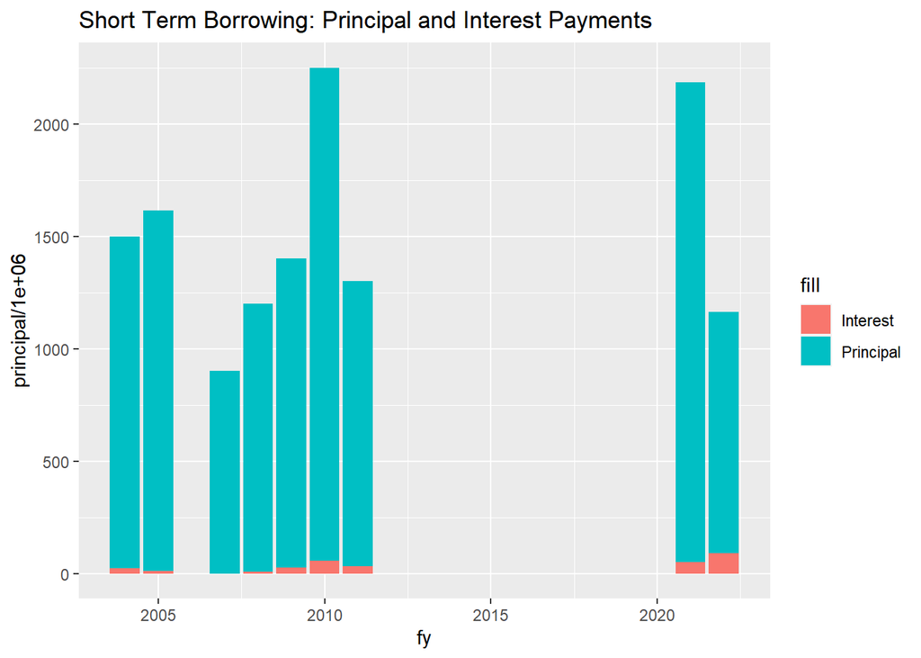

```r
short_debt %>% ggplot() +
  geom_col(aes(x=fy, y=principal/1000000, fill = "Principal"))+
  geom_col(aes(x=fy, y=interest/1000000, fill = "Interest")) +
  labs(title = "Short Term Borrowing: Principal and Interest Payments")
```

```r
capitalprojects <- exp_temp %>%filter(object == "8800")


all_debt <- exp_temp %>%
  filter(fund != "0455" & (object == "8811" |object == "8813" | object == "8800") )%>%
  group_by(fy, object) %>%
  summarize(sum = sum(expenditure, na.rm=TRUE)) %>%
  pivot_wider(names_from = object, values_from = sum) %>%
  mutate(principal = `8811`,
         interest = `8813`,
         CapitalProjects = `8800`,
         ratio = (as.numeric(interest)/as.numeric(principal)))

all_debt %>% select(principal, interest, CapitalProjects, ratio) %>%
  mutate(across(principal:CapitalProjects, ~format(., big.mark= ",", scientific = F)))
```

| fy | principal | interest | CapitalProjects | ratio |
| --- | --- | --- | --- | --- |
| 1998 | 575,371,231 | 259,385,877 | 225,147,958 | 0.4508148 |
| 1999 | 422,975,040 | 267,956,231 | 239,571,392 | 0.6335036 |
| 2000 | 430,464,406 | 287,154,654 | 256,685,875 | 0.6670811 |
| 2001 | 585,553,477 | 336,582,816 | 253,461,423 | 0.5748114 |
| 2002 | 740,370,036 | 382,634,975 | 257,622,074 | 0.5168159 |
| 2003 | 1,658,569,732 | 474,937,865 | 256,264,319 | 0.2863539 |
| 2004 | 1,923,668,657 | 1,019,833,688 | 268,750,574 | 0.5301504 |
| 2005 | 2,153,260,524 | 1,071,877,490 | 279,939,826 | 0.4977928 |
| 2006 | 1,565,449,887 | 1,113,124,277 | 302,328,995 | 0.7110571 |
| 2007 | 1,477,592,635 | 1,115,485,186 | 301,723,144 | 0.7549342 |

[output cut: 15 more lines]

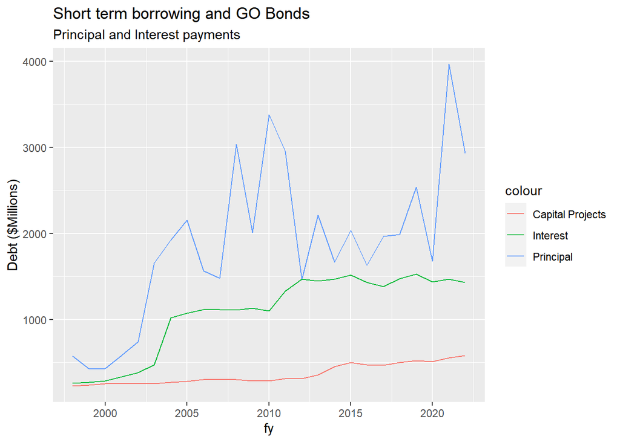

```r
all_debt %>% ggplot() +
  geom_line(aes(x=fy, y=principal/1000000, color = "Principal"))+
  geom_line(aes(x=fy, y=interest/1000000, color = "Interest"))+
  geom_line(aes(x=fy, y = CapitalProjects / 1000000, color = "Capital Projects"))+
  labs(y = "Debt ($Millions)", title = "Short term borrowing and GO Bonds",
       subtitle = "Principal and Interest payments")
```

Capital projects include the IL Civic Center and Build Illinois Bonds. Tollway principal and interest has been dropped from Debt Service but is counted in Tollway Expenditure Cost.

```r
debt_drop <- exp_temp %>%
  filter(object == "8841" |  object == "8811")
# escrow  OR  principle

#debt_drop %>% group_by(fy) %>% summarize(sum = sum(expenditure)) %>% arrange(-fy)


debt_keep <- exp_temp %>%
  filter(fund != "0455" & (object == "8813" | object == "8800" ))
# examine the debt costs we want to include

#debt_keep %>% group_by(fy) %>% summarize(sum = sum(expenditure)) %>% arrange(-fy)


exp_temp <- anti_join(exp_temp, debt_drop)
exp_temp <- anti_join(exp_temp, debt_keep)

debt_keep <- debt_keep %>%
  mutate(
    agency = ifelse(fund != "0455" & (object == "8813" | object == "8800"), "903", as.character(agency)),
    group = ifelse(fund != "0455" & (object == "8813" | object == "8800"), "903", as.character(group)),
    in_ff = ifelse(group == "903", 1, as.character(in_ff)))

debt_keep_yearly <- debt_keep %>% group_by(fy, group) %>% summarize(debt_cost = sum(expenditure,na.rm=TRUE)/1000000) %>% select(-group)
```

### Medicaid

**Medicaid.** That portion of the Healthcare and Family Services (or Public Aid in earlier years, agency code 478) budget for Medical (appr_organization code 65) for awards and grants (object codes 4400 and 4900).

## Add Fiscal Future group codes

```r
exp_temp <- exp_temp %>%
  #mutate(agency = as.numeric(agency) ) %>%
  # arrange(agency)%>%
  mutate(
    group = case_when(
      agency>"100"& agency<"200" ~ "910", # legislative

      agency == "528"  | (agency>"200" & agency<"300") ~ "920", # judicial
      pension>0  ~ "901", # pensions
      (agency>"309" & agency<"400") ~ "930",    # elected officers

      agency == "586" ~ "959", # create new K-12 group

      agency=="402" | agency=="418" | agency=="478" | agency=="444" | agency=="482" ~ as.character(agency), # aging, CFS, HFS, human services, public health
      T ~ as.character(group))
    ) %>%


  mutate(group = case_when(
    agency=="478" & (appr_org=="01" | appr_org == "65" | appr_org=="88") & (object=="4900" | object=="4400") ~ "945", # separates CHIP from health and human services and saves it as Medicaid

    agency == "586" & fund == "0355" ~ "945",  # 586 (Board of Edu) has special education which is part of medicaid

    # OLD CODE: agency == "586" & appr_org == "18" ~ "945", # Spec. Edu Medicaid Matching

    agency=="425" | agency=="466" | agency=="546" | agency=="569" | agency=="578" | agency=="583" | agency=="591" | agency=="592" | agency=="493" | agency=="588" ~ "941", # public safety & Corrections

    agency=="420" | agency=="494" |  agency=="406" | agency=="557" ~ as.character(agency), # econ devt & infra, tollway

    agency=="511" | agency=="554" | agency=="574" | agency=="598" ~ "946",  # Capital improvement

    agency=="422" | agency=="532" ~ as.character(agency), # environment & nat. resources

    agency=="440" | agency=="446" | agency=="524" | agency=="563"  ~ "944", # business regulation

    agency=="492" ~ "492", # revenue

    agency == "416" ~ "416", # central management services
    agency=="448" & fy > 2016 ~ "416", #add DoIT to central management

    T ~ as.character(group))) %>%


  mutate(group = case_when(
    agency=="684" | agency=="691"  ~ as.character(agency),

    agency=="692" | agency=="695" | (agency>"599" & agency<"677") ~ "960", # higher education

    agency=="427"  ~ as.character(agency), # employment security

    agency=="507"|  agency=="442" | agency=="445" | agency=="452" |agency=="458" | agency=="497" ~ "948", # other departments

    # other boards & Commissions
    agency=="503" | agency=="509" | agency=="510" | agency=="565" |agency=="517" | agency=="525" | agency=="526" | agency=="529" | agency=="537" | agency=="541" | agency=="542" | agency=="548" |  agency=="555" | agency=="558" | agency=="559" | agency=="562" | agency=="564" | agency=="568" | agency=="579" | agency=="580" | agency=="587" | agency=="590" | agency=="527" | agency=="585" | agency=="567" | agency=="571" | agency=="575" | agency=="540" | agency=="576" | agency=="564" | agency=="534" | agency=="520" | agency=="506" | agency == "533" ~ "949",

    # non-pension expenditures of retirement funds moved to "Other Departments"
    # should have removed pension expenditures already from exp_temp in Pensions step above
    agency=="131" | agency=="275" | agency=="589" |agency=="593"|agency=="594"|agency=="693" ~ "948",

    T ~ as.character(group))) %>%

  mutate(group_name =
           case_when(
             group == "416" ~ "Central Management",
             group == "478" ~ "Healthcare and Family Services",
             group == "482" ~ "Public Health",
             group == "900" ~ "NOT IN FRAME",
             group == "901" ~ "STATE PENSION CONTRIBUTION",
             group == "903" ~ "DEBT SERVICE",
             group == "910" ~ "LEGISLATIVE"  ,
             group == "920" ~ "JUDICIAL" ,
             group == "930" ~ "ELECTED OFFICERS" ,
             group == "940" ~ "OTHER HEALTH-RELATED",
             group == "941" ~ "PUBLIC SAFETY" ,
             group == "942" ~ "ECON DEVT & INFRASTRUCTURE" ,
             group == "943" ~ "CENTRAL SERVICES",
             group == "944" ~ "BUS & PROFESSION REGULATION" ,
             group == "945" ~ "MEDICAID" ,
             group == "946" ~ "CAPITAL IMPROVEMENT" ,
             group == "948" ~ "OTHER DEPARTMENTS" ,
             group == "949" ~ "OTHER BOARDS & COMMISSIONS" ,
             group == "959" ~ "K-12 EDUCATION" ,
             group == "960" ~ "UNIVERSITY EDUCATION" ,
             group == agency ~ as.character(group),
             TRUE ~ "Check name"),
         year = fy)

exp_temp %>% filter(group_name == "Check name")
```

| fy | fund | fund_name | agency | agency_name | appr_org | org_name | obj_seq_type | appn_net_xfer | expenditure | data_source | object | category | sequence | type | trans_agency | trans_type | wh_approp_name | fund_cat | fund_cat_name.x | expenditurethrough6302022 | fund_ab | fund_ioc | fund_re | a_end | in_ff | fund_name_ab | fund_category | fund_cat_name.y | in_ff_rev | … |
| --- | --- | --- | --- | --- | --- | --- | --- | --- | --- | --- | --- | --- | --- | --- | --- | --- | --- | --- | --- | --- | --- | --- | --- | --- | --- | --- | --- | --- | --- | --- |

```r
#write_csv(exp_temp, "all_expenditures_recoded.csv")
```

# Modify Revenue data

Revenue Categories NOT included in Fiscal Futures:  
- 32. Garnishment-Levies. (State is fiduciary, not beneficiary.)  
- 45. Student Fees-Universities. (Excluded from state-level budget.)  
- 51. Retirement Contributions (of individuals and non-state entities).  
- 66. Proceeds, Investment Maturities. (Not sustainable flow.)  
- 72. Bond Issue Proceeds. (Not sustainable flow.)  
- 75. Inter-Agency Receipts.  
- 79. Cook County Intergovernmental Transfers. (State is not beneficiary.)  
- 85. Short-term Borrowing - 98. Prior Year Refunds.

**All Other Sources**

Expanded to include the following smaller sources:  
- 30. Horse Racing Taxes & Fees.  
- 60. Other Grants and Contracts.  
- 63. Investment Income.

For aggregating revenue, use the rev_1998_2022 dataframe, join the funds_ab_in_2022 file to it, and then join the ioc_source_type file to the dataset. Remember: You need to update the funds_ab_in and ioc_source_type file every year!

```r
# fund info to revenue for all years
rev_temp <- inner_join(rev_1998_2022, funds_ab_in_2022, by = "fund") %>% arrange(source)

# need to update the ioc_source_type file every year!
ioc_source_type <- readxl::read_xlsx("C:/Users/aleaw/OneDrive/Documents/PhD Fall 2021 - Spring 2022/Merriman RA/Fiscal Futures FY2022/Replication-Files/ioc_source_updated22_AWM.xlsx")

rev_temp <- left_join(rev_temp, ioc_source_type, by = "source")
# automatically used source, source name does not match for the join to work using source_name
```

Update Agencies: Early agencies replaced by successors

```r
# recodes old agency numbers to consistent agency number
rev_temp <- rev_temp %>%
  mutate(agency = case_when(
    (agency=="438"| agency=="475" |agency == "505") ~ "440",
    # financial institution &  professional regulation &
     # banks and real estate  --> coded as  financial and professional reg
    agency == "473" ~ "588", # nuclear safety moved into IEMA
    (agency =="531" | agency =="577") ~ "532", # coded as EPA
    (agency =="556" | agency == "538") ~ "406", # coded as agriculture
    agency == "560" ~ "592", # IL finance authority (fire trucks and agriculture stuff)to state fire marshal
    agency == "570" & fund == "0011" ~ "494",   # city of Chicago road fund to transportation
    TRUE ~ (as.character(agency))))
```

### Federal to State Transfers

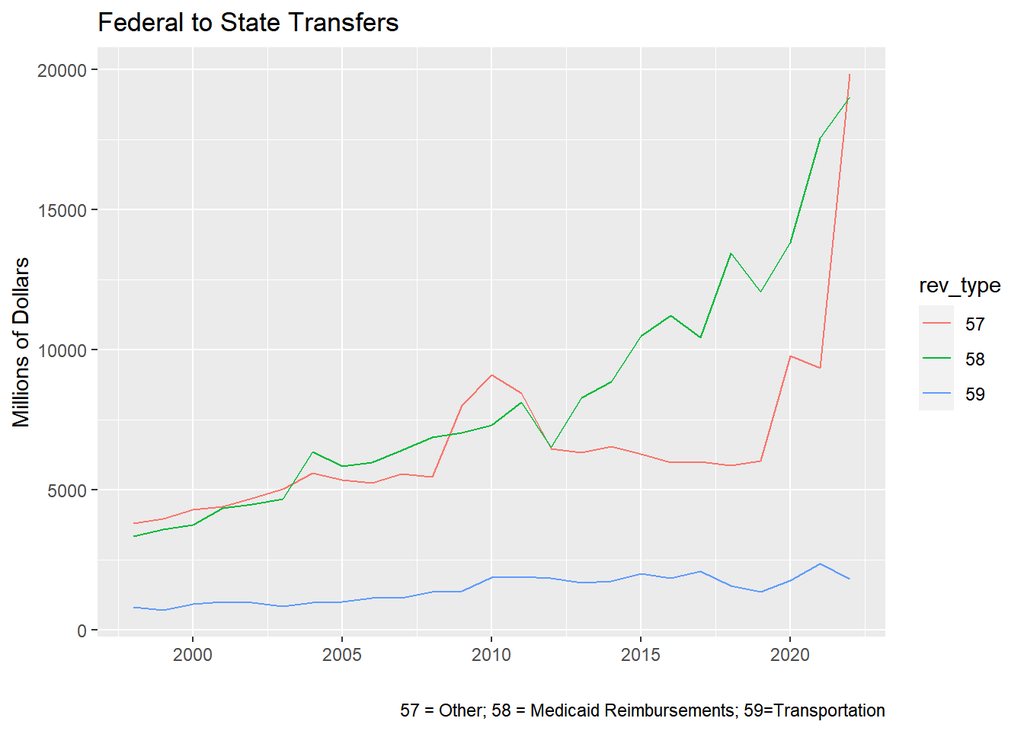

```r
rev_temp <- rev_temp %>%
  mutate(
    rev_type = ifelse(rev_type=="57" & agency=="478" & (source=="0618"|source=="2364"|source=="0660"|source=="1552"| source=="2306"| source=="2076"|source=="0676"|source=="0692"), "58", rev_type),
    rev_type_name = ifelse(rev_type=="58", "FEDERAL TRANSPORTATION", rev_type_name),
    rev_type = ifelse(rev_type=="57" & agency=="494", "59", rev_type),
    rev_type_name = ifelse(rev_type=="59", "FEDERAL TRANSPORTATION", rev_type_name),
    rev_type_name = ifelse(rev_type=="57", "FEDERAL OTHER", rev_type_name),
    rev_type = ifelse(rev_type=="6", "06", rev_type),
    rev_type = ifelse(rev_type=="9", "09", rev_type))

rev_temp %>%
  filter(rev_type == "58" | rev_type == "59" | rev_type == "57") %>%
  group_by(fy, rev_type, rev_type_name) %>%
  summarise(receipts = sum(receipts, na.rm = TRUE)/1000000) %>%
  ggplot() +
  geom_line(aes(x=fy, y=receipts,color=rev_type)) +
  labs(title = "Federal to State Transfers",
       y = "Millions of Dollars", x = "",
       caption = "57 = Other; 58 = Medicaid Reimbursements; 59=Transportation")
```

### Pension Contributions

Employee contributions to pension are a revenue source for the state. In order to get the net cost of pensions for the state, employee contributions should be subtracted in order to calculate net costs.

- current year employee revenue source = 0573
- contributions by employee == 572 (stops at 2011)

```r
#pension_rev_check <- rev_temp %>% filter(source == "0572" | source == "0573" | source == "0574" | source == "0577" | source == "1982" | source == "2567")

#write_csv(pension_rev_check, "pension_revenue_check.csv")


# current year employee revenue source = 0573, contributions by employee == 572 (stops at 2011)
pension_rev <- rev_temp %>%
  filter(rev_type == "51" & source == "0573" | source == "0572")


rev_type <- anti_join(rev_temp, pension_rev)

pension_rev_yearly <- rev_temp %>%
  filter(rev_type == "51" & source == "0573" | source == "0572") %>%
  group_by(fy, rev_type) %>%
  summarise(pension_rev_sum = sum(receipts, na.rm=TRUE)/1000000) %>% select(-rev_type)
```

`pension_rev` should be subtracted from the state pension expenditures. Employee contributions to pensions are a revenue source. We want net pension cost, therefore subtract employee contributions from pension costs.

### Health Insurance Premiums from Employees

Employee insurance premiums for healthcare are a revenue source for the state. In order to get the true cost of State Employee Healthcare, total employee insurance premiums should be subtracted from the healthcare expenditure total (exp_904 - premiums). Gather all employee premiums into `opt_premiums` and subtract it from the Expenditure table after aggregating and pivoting steps.

```r
opt_premiums_CHECK <- rev_temp %>%
  filter((fund=="0907" | fund == "0457") & (source=="0120" | source=="0121" | (source>"0345" & source<"0357") | (source>"2199" & source<"2209")                                            )
         )

#collect optional insurance premiums to fund 0907 for use in eehc expenditure
rev_temp <- rev_temp %>%
  mutate(med_option_recent = ifelse(
    fund=="0907" & (source=="0120"| source=="0121"| (source>"0345" & source<"0357")|(source>"2199" & source<"2209")), 1, 0),

    # adds more rev_type codes
    rev_type = case_when(
      fund =="0427" ~ "12", # pub utility tax
      fund == "0742" | fund == "0473" ~ "24", # insurance and fees
      fund == "0976" ~ "36",# receipts from rev producing
      fund == "0392" |fund == "0723" ~ "39", # licenses and fees
      fund == "0656" ~ "78", #all other rev sources
      TRUE ~ as.character(rev_type)))
# if not mentioned, then rev_type as it was



# optional insurance premiums = employee insurance premiums
med_option_recent <- rev_temp %>%
  group_by(fy, med_option_recent) %>%
  summarize(med_option_amt_recent = sum(receipts)/1000000) %>%
  filter(med_option_recent == 1) %>%
  rename(year = fy) %>%
  select(-med_option_recent)

med_option_long <- rev_temp %>%  filter(med_option_recent == 1)
# 361 observations have med_option_recent == 1


rev_temp <- rev_temp %>% filter(med_option_recent != 1)
# could also do an antijoin with rev_temp and med_option dataframes
```

You must then subtract the employee premiums from the state healthcare expenditures totals. Employee premiums on the revenue side should have receipts coded as $0 or be dropped using anti_join().

### Transfers in and Out:

```r
rev_temp <- rev_temp %>%
  #filter(in_ff == 1) %>%
  mutate(local = ifelse(is.na(local), 0, local)) %>% # drops all revenue observations that were coded as "local == 1"
  filter(local != 1)

# 1175 doesnt exist?
in_from_out <- c("0847", "0867", "1175", "1176", "1177", "1178", "1181", "1182", "1582", "1592", "1745", "1982", "2174", "2264")

# what does this actually include:
# all are items with rev_type = 75 originally.
in_out_df <- rev_type %>%
  mutate(infromout = ifelse(source %in% in_from_out, 1, 0)) %>%
  filter(infromout == 1)

rev_temp <- rev_temp %>%
  mutate(rev_type_new = ifelse(source %in% in_from_out, "76", rev_type))
# if source contains any of the codes in in_from_out, code them as 76 (all other rev).
```

```r
# revenue types to drop
#drop_type <- c("32", "45", "51", "66", "72", "75", "79", "98")

# drops Blank, Student Fees, Retirement contributions, proceeds/investments,
# bond issue proceeds, interagency receipts, cook IGT, Prior year refunds.


#rev_temp <- rev_temp %>% filter(!rev_type_new %in% drop_type)
# keep observations that do not have a revenue type mentioned in drop_type

#table(rev_temp$rev_type_new)

rev_temp %>%
  group_by(fy, rev_type_new) %>%
  summarize(total_reciepts = sum(receipts)/1000000) %>%
  pivot_wider(names_from = rev_type_new, values_from = total_reciepts, names_prefix = "rev_")
```

| fy | rev_02 | rev_03 | rev_06 | rev_09 | rev_12 | rev_15 | rev_18 | rev_21 | rev_24 | rev_27 | rev_30 | rev_31 | rev_33 | rev_35 | rev_36 | rev_39 | rev_42 | rev_45 | rev_48 | rev_54 | rev_57 | rev_58 | rev_59 | rev_60 | rev_63 | rev_66 | rev_72 | rev_75 | rev_76 | … |
| --- | --- | --- | --- | --- | --- | --- | --- | --- | --- | --- | --- | --- | --- | --- | --- | --- | --- | --- | --- | --- | --- | --- | --- | --- | --- | --- | --- | --- | --- | --- |
| 1998 | 6846.827 | 1860.322 | 7198.401 | 1300.658 | 1193.328 | 464.2421 | 57.03395 | 250.4342 | 132.3373 | 122.7717 | 42.827602 | 543.1538 | 834.6949 | 244.6849 | 727.7252 | 304.8013 | 747.4372 | 21.34316 | 210.4965 | 138.1076 | 3747.793 | 3339.059 | 835.1585 | 2.73917896 | 277.61175 | 3.64881666 | 906.1658 | 896.3666 | 59.54166 | … |
| 1999 | 7225.764 | 1854.888 | 7646.728 | 1328.799 | 1423.402 | 499.0560 | 57.23468 | 346.9777 | 248.5650 | 121.3476 | 41.640032 | 548.5763 | 844.8850 | 268.8884 | 715.9857 | 328.4494 | 773.0030 | 19.32112 | 309.8295 | 157.9744 | 3924.452 | 3599.680 | 725.9854 | 2.53047152 | 306.53295 | 2.96435262 | 870.6214 | 974.1898 | 73.16676 | … |
| 2000 | 7685.811 | 2067.907 | 8218.148 | 1356.283 | 1524.369 | 467.3495 | 127.86824 | 348.0088 | 267.6100 | 143.9242 | 22.584853 | 649.1760 | 814.2806 | 275.4470 | 736.8125 | 402.6987 | 973.4303 | 18.91677 | 435.9784 | 180.3469 | 4232.726 | 3763.416 | 927.4700 | 2.91999703 | 349.50797 | 3.93238384 | 988.1446 | 1115.9434 | 70.72210 | … |
| 2001 | 7995.794 | 1789.672 | 8175.164 | 1366.563 | 1605.878 | 472.6152 | 124.31482 | 361.0388 | 298.2466 | 150.6893 | 12.826824 | 678.1501 | 765.0459 | 281.5546 | 743.0530 | 526.6566 | 1134.5203 | 18.82535 | 490.7099 | 202.9800 | 4309.878 | 4355.735 | 1019.2127 | 3.08349373 | 425.44721 | 3.47112882 | 1639.3889 | 1456.3934 | 68.16008 | … |
| 2002 | 7471.385 | 1383.822 | 8279.112 | 1373.522 | 1568.098 | 468.7761 | 122.00049 | 329.1675 | 322.8413 | 165.3039 | 12.595321 | 655.9115 | 825.5416 | 277.9858 | 749.8397 | 554.1947 | 1177.6634 | 14.31212 | 540.3113 | 250.1362 | 4578.864 | 4484.163 | 995.8889 | 3.38917782 | 220.98766 | 9.33545023 | 2570.7865 | 1619.5399 | 75.64057 | … |
| 2003 | 7340.982 | 1293.187 | 8227.828 | 1388.316 | 1439.252 | 699.7512 | 122.76700 | 236.9498 | 372.0469 | 147.4289 | 11.915672 | 817.9764 | 817.0446 | 270.5879 | 742.1438 | 553.7608 | 1107.2757 | 16.01571 | 615.9942 | 351.0742 | 5012.430 | 4673.566 | 846.3242 | 3.92775617 | 114.12964 | 5.37309286 | 14596.9957 | 1550.8350 | 79.62673 | … |
| 2004 | 7272.488 | 1596.453 | 8636.675 | 1423.884 | 1536.122 | 760.2273 | 126.77083 | 221.7226 | 473.2137 | 169.4077 | 12.039788 | 901.1004 | 879.9045 | 297.9297 | 866.0812 | 812.3725 | 1161.7423 | 21.61036 | 708.2093 | 538.6650 | 5565.795 | 6359.506 | 998.6016 | 4.83449371 | 91.83820 | 4.62804140 | 3261.1745 | 1868.5914 | 77.85041 | … |
| 2005 | 7978.780 | 1971.814 | 8980.959 | 1434.595 | 1501.032 | 656.4727 | 147.23758 | 310.4202 | 434.4367 | 189.7033 | 11.653864 | 1601.3355 | 903.4691 | 320.4917 | 823.6036 | 875.9698 | 1168.7572 | 34.61758 | 751.6648 | 627.4337 | 5313.030 | 5853.288 | 1001.7689 | 0.57045753 | 129.65269 | 3.51439918 | 1908.1182 | 1753.1334 | 182.76862 | … |
| 2006 | 8635.104 | 2400.269 | 9638.334 | 1446.067 | 1549.563 | 640.3341 | 152.29981 | 271.8636 | 404.4333 | 189.1277 | 10.545724 | 889.6801 | 981.0635 | 351.2791 | 878.3029 | 808.4360 | 1295.8877 | 35.83139 | 766.5279 | 728.4934 | 5210.833 | 5996.508 | 1141.1534 | 0.55437700 | 272.23392 | 3.07383276 | 3080.8473 | 2061.0905 | 174.60474 | … |
| 2007 | 9408.437 | 2936.358 | 9785.236 | 1453.707 | 1604.179 | 638.7959 | 155.68041 | 264.3954 | 408.5731 | 201.3656 | 8.512082 | 1528.8635 | 956.9057 | 354.1772 | 1108.4448 | 794.3926 | 1288.0729 | 56.93422 | 763.9175 | 401.6625 | 5523.924 | 6420.817 | 1159.1214 | 1.07916200 | 379.06716 | 2.95194104 | 2049.1252 | 2108.3273 | 157.85190 | … |

[output cut: 15 more lines]

```r
# combines smallest 4  categories to to "Other"
# they were the 4 smallest in past years, are they still the 4 smallest?

#rev_temp <- rev_temp %>%
#  mutate(rev_type_new = ifelse(rev_type=="30" | rev_type=="60" | rev_type=="63" | rev_type=="76", "78", rev_type_new))


#table(rev_temp$rev_type_new)  # check work


rm(rev_1998_2022)
rm(exp_1998_2022)
```

# Pivoting and Merging

## Revenues

```r
ff_rev <- rev_temp %>%
  group_by(rev_type_new, fy) %>%
  summarize(sum_receipts = sum(receipts, na.rm=TRUE)/1000000 ) %>%
  pivot_wider(names_from = "rev_type_new", values_from = "sum_receipts", names_prefix = "rev_")

ff_rev<- left_join(ff_rev, tax_refund)

ff_rev <- mutate_all(ff_rev, ~replace_na(.,0))


ff_rev <- ff_rev %>%
  mutate(rev_02 = rev_02 - ref_02,
         rev_03 = rev_03 - ref_03,
         rev_06 = rev_06 - ref_06,
         rev_09 = rev_09 - ref_09,
         rev_21 = rev_21 - ref_21,
         rev_24 = rev_24 - ref_24,
         rev_35 = rev_35 - ref_35)
         # %>% select(-c(ref_02:ref_35 )) # remove refund variables since they were subtracted above

ff_rev
```

| fy | rev_02 | rev_03 | rev_06 | rev_09 | rev_12 | rev_15 | rev_18 | rev_21 | rev_24 | rev_27 | rev_30 | rev_31 | rev_32 | rev_33 | rev_35 | rev_36 | rev_39 | rev_42 | rev_45 | rev_48 | rev_51 | rev_54 | rev_57 | rev_58 | rev_59 | rev_60 | rev_63 | rev_66 | rev_72 | … |
| --- | --- | --- | --- | --- | --- | --- | --- | --- | --- | --- | --- | --- | --- | --- | --- | --- | --- | --- | --- | --- | --- | --- | --- | --- | --- | --- | --- | --- | --- | --- |
| 1998 | 6756.478 | 2079.812 | 7392.394 | 1298.050 | 1193.481 | 464.8931 | 57.03395 | 246.0342 | 1442.979 | 123.1081 | 42.827602 | 543.1538 | 11.52549 | 834.6949 | 278.6099 | 745.3290 | 468.1727 | 747.4372 | 21.34316 | 210.4965 | 904.3967 | 139.5624 | 3803.806 | 3339.059 | 835.1585 | 2.73917896 | 489.67310 | 93.200183 | 906.1658 | … |
| 1999 | 7170.199 | 2052.875 | 7848.046 | 1320.611 | 1423.402 | 501.6504 | 57.23468 | 342.8019 | 1581.536 | 122.2324 | 41.640032 | 548.5763 | 16.15532 | 844.8850 | 290.8455 | 806.4267 | 502.0543 | 773.0030 | 19.32112 | 309.8295 | 1055.8312 | 160.3118 | 3976.303 | 3599.680 | 725.9854 | 2.53047152 | 540.16838 | 30.569448 | 870.6214 | … |
| 2000 | 7497.786 | 2197.584 | 8428.076 | 1343.546 | 1524.561 | 470.9767 | 127.86824 | 340.9423 | 1716.108 | 144.5158 | 23.664134 | 649.1760 | 22.42021 | 814.2806 | 290.1940 | 809.0941 | 581.8886 | 973.4303 | 18.91677 | 435.9784 | 1102.2261 | 182.5925 | 4298.967 | 3763.416 | 927.4700 | 2.91999703 | 917.50177 | 39.036946 | 988.1446 | … |
| 2001 | 7766.895 | 2005.824 | 8383.948 | 1355.006 | 1613.201 | 476.1611 | 140.64339 | 353.5388 | 1928.861 | 153.8777 | 12.826824 | 678.1501 | 41.12471 | 765.0459 | 311.3838 | 820.1045 | 710.4522 | 1134.5203 | 18.82535 | 490.7099 | 1124.2641 | 209.3464 | 4408.547 | 4355.735 | 1019.2127 | 3.08349373 | 723.25619 | 44.083695 | 1639.3889 | … |
| 2002 | 7253.297 | 1616.624 | 8475.063 | 1357.865 | 1568.458 | 472.5677 | 140.85360 | 322.1221 | 2139.059 | 165.4735 | 12.595321 | 655.9115 | 27.18016 | 825.5416 | 298.0062 | 864.6292 | 730.7941 | 1177.6634 | 14.31212 | 540.3113 | 1151.0338 | 262.4901 | 4703.638 | 4484.163 | 995.8889 | 3.38917782 | 517.00824 | 81.411932 | 2570.7865 | … |
| 2003 | 6734.375 | 1418.061 | 8436.059 | 1373.788 | 1507.324 | 702.9849 | 141.98147 | 230.3980 | 2439.464 | 147.8655 | 11.915672 | 817.9969 | 36.69634 | 817.0446 | 295.3941 | 892.4596 | 722.6746 | 1107.2757 | 16.01571 | 615.9942 | 1292.1616 | 353.3599 | 5047.121 | 4673.566 | 846.3242 | 3.92775617 | 372.41972 | 145.462004 | 15221.9957 | … |
| 2004 | 7134.007 | 1832.944 | 8873.108 | 1405.895 | 1718.961 | 760.2273 | 147.87581 | 228.5158 | 7131.386 | 171.6743 | 12.039788 | 901.1340 | 31.52365 | 879.9045 | 332.3272 | 1011.4408 | 994.6693 | 1161.7423 | 21.61036 | 708.2093 | 1258.3004 | 542.6818 | 5597.914 | 6359.506 | 998.6016 | 4.83899371 | 293.41739 | 424.796624 | 3261.1745 | … |
| 2005 | 7829.676 | 2290.272 | 9229.501 | 1419.873 | 1726.509 | 656.4727 | 147.23758 | 305.2952 | 3065.755 | 191.1564 | 11.653864 | 1601.3630 | 31.12963 | 903.4691 | 368.5514 | 970.6668 | 1031.5412 | 1168.7572 | 34.61758 | 751.6648 | 1636.1621 | 629.0976 | 5357.166 | 5853.288 | 1001.7689 | 0.57045753 | 370.17716 | 551.214399 | 1908.1182 | … |
| 2006 | 8470.322 | 2699.330 | 9909.922 | 1430.052 | 1788.977 | 640.3341 | 152.29981 | 263.7400 | 3356.301 | 189.2092 | 10.545724 | 889.6921 | 28.54127 | 981.0635 | 403.3334 | 1029.7821 | 967.1830 | 1295.8877 | 35.83139 | 769.2226 | 1388.4347 | 730.3057 | 5253.930 | 5996.508 | 1141.1534 | 0.55437700 | 465.14502 | 762.073833 | 3080.8473 | … |
| 2007 | 9290.632 | 3326.601 | 10066.909 | 1439.744 | 1850.968 | 638.7959 | 155.68041 | 255.3956 | 3598.266 | 201.4542 | 8.512082 | 1528.8815 | 31.97948 | 956.9057 | 416.9814 | 1257.1372 | 960.8853 | 1288.0729 | 56.93422 | 803.4696 | 1594.3146 | 403.0986 | 5584.576 | 6420.817 | 1159.1214 | 1.07916200 | 560.04180 | 644.951941 | 2049.1252 | … |

[output cut: 15 more lines]

Since I already pivot_wider()ed the table in the previous code chunk, I now change each column’s name by using rename() to set new variable names. Ideally the final dataframe would have both the variable name and the variable label but I have not done that yet.

```r
# revenue types to drop
#drop_type <- c("32", "45", "51", "66", "72", "75", "79", "98", "99")

# drops Blank, Student Fees, Retirement contributions, proceeds/investments,
# bond issue proceeds, interagency receipts, cook IGT, Prior year refunds.



# combines smallest 4  categories to to "Other"
#rev_temp <- rev_temp %>%
#  mutate(rev_type_new = ifelse(rev_type=="30" | rev_type=="60" | rev_type=="63" | rev_type=="76", "78", rev_type_new))


aggregate_rev_labels <- ff_rev %>%
  rename("INDIVIDUAL INCOME TAXES, gross of local, net of refunds" = rev_02,
         "CORPORATE INCOME TAXES, gross of PPRT, net of refunds" = rev_03,
         "SALES TAXES, gross of local share" = rev_06 ,
         "MOTOR FUEL TAX, gross of local share, net of refunds" = rev_09 ,
         "PUBLIC UTILITY TAXES, gross of PPRT" = rev_12,
         "CIGARETTE TAXES" = rev_15 ,
         "LIQUOR GALLONAGE TAXES" = rev_18,
         "INHERITANCE TAX" = rev_21,
         "INSURANCE TAXES&FEES&LICENSES, net of refunds" = rev_24 ,
         "CORP FRANCHISE TAXES & FEES" = rev_27,
        "HORSE RACING TAXES & FEES" = rev_30,  # in Other
         "MEDICAL PROVIDER ASSESSMENTS" = rev_31 ,
         "GARNISHMENT-LEVIES " = rev_32 , # dropped
         "LOTTERY RECEIPTS" = rev_33 ,
         "OTHER TAXES" = rev_35,
         "RECEIPTS FROM REVENUE PRODUCNG" = rev_36,
         "LICENSES, FEES & REGISTRATIONS" = rev_39 ,
         "MOTOR VEHICLE AND OPERATORS" = rev_42 ,
          "STUDENT FEES-UNIVERSITIES" = rev_45,   # dropped
         "RIVERBOAT WAGERING TAXES" = rev_48 ,
         "RETIREMENT CONTRIBUTIONS " = rev_51, # dropped
         "GIFTS AND BEQUESTS" = rev_54,
         "FEDERAL OTHER" = rev_57 ,
         "FEDERAL MEDICAID" = rev_58,
         "FEDERAL TRANSPORTATION" = rev_59 ,
         "OTHER GRANTS AND CONTRACTS" = rev_60, #other
        "INVESTMENT INCOME" = rev_63, # other
         "PROCEEDS,INVESTMENT MATURITIES" = rev_66 , #dropped
         "BOND ISSUE PROCEEDS" = rev_72,  #dropped
         "INTER-AGENCY RECEIPTS" = rev_75,  #dropped
        "TRANSFER IN FROM OUT FUNDS" = rev_76,  #other
         "ALL OTHER SOURCES" = rev_78,
         # "COOK COUNTY IGT" = rev_79, #dropped
       # "Short term borrowing" = rev_85,
          "PRIOR YEAR REFUNDS" = rev_98, #dropped
        "NAs" = rev_NA,
        "Statutory Transfers" = rev_99
  )

aggregate_rev_labels
```

| fy | INDIVIDUAL INCOME TAXES, gross of local, net of refunds | CORPORATE INCOME TAXES, gross of PPRT, net of refunds | SALES TAXES, gross of local share | MOTOR FUEL TAX, gross of local share, net of refunds | PUBLIC UTILITY TAXES, gross of PPRT | CIGARETTE TAXES | LIQUOR GALLONAGE TAXES | INHERITANCE TAX | INSURANCE TAXES&FEES&LICENSES, net of refunds | CORP FRANCHISE TAXES & FEES | HORSE RACING TAXES & FEES | MEDICAL PROVIDER ASSESSMENTS | GARNISHMENT-LEVIES | LOTTERY RECEIPTS | OTHER TAXES | RECEIPTS FROM REVENUE PRODUCNG | LICENSES, FEES & REGISTRATIONS | MOTOR VEHICLE AND OPERATORS | STUDENT FEES-UNIVERSITIES | RIVERBOAT WAGERING TAXES | RETIREMENT CONTRIBUTIONS | GIFTS AND BEQUESTS | FEDERAL OTHER | FEDERAL MEDICAID | FEDERAL TRANSPORTATION | OTHER GRANTS AND CONTRACTS | INVESTMENT INCOME | PROCEEDS,INVESTMENT MATURITIES | BOND ISSUE PROCEEDS | … |
| --- | --- | --- | --- | --- | --- | --- | --- | --- | --- | --- | --- | --- | --- | --- | --- | --- | --- | --- | --- | --- | --- | --- | --- | --- | --- | --- | --- | --- | --- | --- |
| 1998 | 6756.478 | 2079.812 | 7392.394 | 1298.050 | 1193.481 | 464.8931 | 57.03395 | 246.0342 | 1442.979 | 123.1081 | 42.827602 | 543.1538 | 11.52549 | 834.6949 | 278.6099 | 745.3290 | 468.1727 | 747.4372 | 21.34316 | 210.4965 | 904.3967 | 139.5624 | 3803.806 | 3339.059 | 835.1585 | 2.73917896 | 489.67310 | 93.200183 | 906.1658 | … |
| 1999 | 7170.199 | 2052.875 | 7848.046 | 1320.611 | 1423.402 | 501.6504 | 57.23468 | 342.8019 | 1581.536 | 122.2324 | 41.640032 | 548.5763 | 16.15532 | 844.8850 | 290.8455 | 806.4267 | 502.0543 | 773.0030 | 19.32112 | 309.8295 | 1055.8312 | 160.3118 | 3976.303 | 3599.680 | 725.9854 | 2.53047152 | 540.16838 | 30.569448 | 870.6214 | … |
| 2000 | 7497.786 | 2197.584 | 8428.076 | 1343.546 | 1524.561 | 470.9767 | 127.86824 | 340.9423 | 1716.108 | 144.5158 | 23.664134 | 649.1760 | 22.42021 | 814.2806 | 290.1940 | 809.0941 | 581.8886 | 973.4303 | 18.91677 | 435.9784 | 1102.2261 | 182.5925 | 4298.967 | 3763.416 | 927.4700 | 2.91999703 | 917.50177 | 39.036946 | 988.1446 | … |
| 2001 | 7766.895 | 2005.824 | 8383.948 | 1355.006 | 1613.201 | 476.1611 | 140.64339 | 353.5388 | 1928.861 | 153.8777 | 12.826824 | 678.1501 | 41.12471 | 765.0459 | 311.3838 | 820.1045 | 710.4522 | 1134.5203 | 18.82535 | 490.7099 | 1124.2641 | 209.3464 | 4408.547 | 4355.735 | 1019.2127 | 3.08349373 | 723.25619 | 44.083695 | 1639.3889 | … |
| 2002 | 7253.297 | 1616.624 | 8475.063 | 1357.865 | 1568.458 | 472.5677 | 140.85360 | 322.1221 | 2139.059 | 165.4735 | 12.595321 | 655.9115 | 27.18016 | 825.5416 | 298.0062 | 864.6292 | 730.7941 | 1177.6634 | 14.31212 | 540.3113 | 1151.0338 | 262.4901 | 4703.638 | 4484.163 | 995.8889 | 3.38917782 | 517.00824 | 81.411932 | 2570.7865 | … |
| 2003 | 6734.375 | 1418.061 | 8436.059 | 1373.788 | 1507.324 | 702.9849 | 141.98147 | 230.3980 | 2439.464 | 147.8655 | 11.915672 | 817.9969 | 36.69634 | 817.0446 | 295.3941 | 892.4596 | 722.6746 | 1107.2757 | 16.01571 | 615.9942 | 1292.1616 | 353.3599 | 5047.121 | 4673.566 | 846.3242 | 3.92775617 | 372.41972 | 145.462004 | 15221.9957 | … |
| 2004 | 7134.007 | 1832.944 | 8873.108 | 1405.895 | 1718.961 | 760.2273 | 147.87581 | 228.5158 | 7131.386 | 171.6743 | 12.039788 | 901.1340 | 31.52365 | 879.9045 | 332.3272 | 1011.4408 | 994.6693 | 1161.7423 | 21.61036 | 708.2093 | 1258.3004 | 542.6818 | 5597.914 | 6359.506 | 998.6016 | 4.83899371 | 293.41739 | 424.796624 | 3261.1745 | … |
| 2005 | 7829.676 | 2290.272 | 9229.501 | 1419.873 | 1726.509 | 656.4727 | 147.23758 | 305.2952 | 3065.755 | 191.1564 | 11.653864 | 1601.3630 | 31.12963 | 903.4691 | 368.5514 | 970.6668 | 1031.5412 | 1168.7572 | 34.61758 | 751.6648 | 1636.1621 | 629.0976 | 5357.166 | 5853.288 | 1001.7689 | 0.57045753 | 370.17716 | 551.214399 | 1908.1182 | … |
| 2006 | 8470.322 | 2699.330 | 9909.922 | 1430.052 | 1788.977 | 640.3341 | 152.29981 | 263.7400 | 3356.301 | 189.2092 | 10.545724 | 889.6921 | 28.54127 | 981.0635 | 403.3334 | 1029.7821 | 967.1830 | 1295.8877 | 35.83139 | 769.2226 | 1388.4347 | 730.3057 | 5253.930 | 5996.508 | 1141.1534 | 0.55437700 | 465.14502 | 762.073833 | 3080.8473 | … |
| 2007 | 9290.632 | 3326.601 | 10066.909 | 1439.744 | 1850.968 | 638.7959 | 155.68041 | 255.3956 | 3598.266 | 201.4542 | 8.512082 | 1528.8815 | 31.97948 | 956.9057 | 416.9814 | 1257.1372 | 960.8853 | 1288.0729 | 56.93422 | 803.4696 | 1594.3146 | 403.0986 | 5584.576 | 6420.817 | 1159.1214 | 1.07916200 | 560.04180 | 644.951941 | 2049.1252 | … |

[output cut: 15 more lines]

```r
# Still contains columns that should be dropped for the clean final aggregate table. Drop the variables I don't want in the output table in the "graphs" section.
```

## Expenditures

Create state employee healthcare costs that reflects the health costs minus the optional insurance premiums that came in ($904\_new = 904 - med\_option\_amt\_recent$).

Create exp_970 for all local government transfers (exp_971 + exp_972 + exp_975 + exp_976).

```r
ff_exp <- exp_temp %>%
  group_by(fy, group) %>%
  summarize(sum_expenditures = sum(expenditure, na.rm=TRUE)/1000000 ) %>%
  pivot_wider(names_from = "group", values_from = "sum_expenditures", names_prefix = "exp_")%>%

    left_join(debt_keep_yearly) %>%
  mutate(exp_903 = debt_cost) %>%

    left_join(healthcare_costs_yearly) %>%

  # join state employee healthcare and subtract employee premiums
  left_join(med_option_recent, by = c("fy" = "year")) %>%
  mutate(exp_904_new = (`healthcare_cost` - `med_option_amt_recent`)) %>% # state employee healthcare premiums

  left_join(pension_rev_yearly) %>%
      mutate(exp_901_new = exp_901 - pension_rev_sum) %>% #employee pension contributions


  # join local transfers and create exp_970
  left_join(transfers) %>%
  mutate(exp_970 = exp_971 + exp_972  + exp_975 + exp_976)

ff_exp<- ff_exp %>% select(-c(exp_901, med_option_amt_recent, debt_cost, healthcare_cost, pension_rev_sum, exp_971:exp_976)) # drop unwanted columns
ff_exp
```

| fy | exp_402 | exp_406 | exp_416 | exp_418 | exp_420 | exp_422 | exp_426 | exp_427 | exp_444 | exp_478 | exp_482 | exp_492 | exp_494 | exp_532 | exp_557 | exp_684 | exp_691 | exp_910 | exp_920 | exp_930 | exp_941 | exp_944 | exp_945 | exp_946 | exp_948 | exp_949 | exp_959 | exp_960 | exp_903 | … |
| --- | --- | --- | --- | --- | --- | --- | --- | --- | --- | --- | --- | --- | --- | --- | --- | --- | --- | --- | --- | --- | --- | --- | --- | --- | --- | --- | --- | --- | --- | --- |
| 1998 | 214.6376 | 73.17255 | 354.3675 | 1289.563 | 462.7255 | 191.8757 | 957.626 | 166.4870 | 3881.039 | 109.5875 | 157.6014 | 411.7969 | 1956.822 | 305.3060 | 367.4203 | 284.5138 | 479.9804 | 59.49046 | 262.7111 | 398.3977 | 424.4396 | 143.4614 | 5398.441 | 255.87193 | 395.81538 | 92.13356 | 5068.578 | 1315.1962 | 484.5338 | … |
| 1999 | 235.7606 | 87.70511 | 395.8145 | 1329.345 | 522.9768 | 228.0308 | 1044.705 | 166.2004 | 4052.750 | 114.2579 | 164.0232 | 430.0348 | 1864.183 | 314.3530 | 461.1122 | 304.9574 | 488.0393 | 62.18552 | 289.3038 | 426.2109 | 444.1802 | 153.4833 | 5767.258 | 399.66740 | 370.25272 | 104.04246 | 5587.952 | 1390.7676 | 507.5276 | … |
| 2000 | 260.4630 | 102.49971 | 405.9484 | 1341.543 | 703.3941 | 267.7414 | 1125.874 | 169.7855 | 4158.558 | 134.4224 | 179.2081 | 435.0732 | 2447.330 | 352.4595 | 434.6787 | 308.6425 | 502.1614 | 67.93008 | 325.1410 | 470.3569 | 467.1192 | 123.8859 | 6442.317 | 828.09202 | 374.49925 | 128.63144 | 6024.689 | 1468.7336 | 543.8405 | … |
| 2001 | 283.6808 | 113.95363 | 404.8524 | 1357.084 | 762.4495 | 307.9027 | 1200.026 | 268.9663 | 4473.465 | 133.2336 | 220.5127 | 794.5102 | 2682.187 | 385.5018 | 346.1392 | 327.9665 | 545.6221 | 73.03187 | 335.0885 | 538.3159 | 488.5881 | 130.1371 | 7187.341 | 889.81010 | 380.87623 | 136.47129 | 6389.910 | 1550.4541 | 590.0442 | … |
| 2002 | 297.1434 | 114.70770 | 393.5432 | 1344.742 | 810.1440 | 347.3659 | 1256.164 | 324.2663 | 4482.840 | 139.4969 | 263.8100 | 659.3818 | 3186.218 | 462.0491 | 392.7439 | 402.5394 | 590.4946 | 78.64442 | 366.6611 | 560.3925 | 486.0726 | 132.6089 | 7291.789 | 1149.07148 | 363.07480 | 140.30385 | 6629.894 | 1663.1696 | 640.2570 | … |
| 2003 | 303.7034 | 89.70322 | 395.0134 | 1281.919 | 828.4200 | 311.5892 | 1171.980 | 361.7048 | 4398.816 | 287.8951 | 239.8246 | 520.6695 | 3254.999 | 458.7148 | 360.7329 | 417.7234 | 579.6236 | 72.29653 | 360.6154 | 541.5032 | 499.0676 | 131.2831 | 7900.568 | 1075.28929 | 365.94014 | 88.79295 | 6690.742 | 1554.7814 | 731.2022 | … |
| 2004 | 313.5735 | 81.37537 | 474.5009 | 1251.765 | 924.2960 | 270.5926 | 1193.815 | 191.0520 | 4586.190 | 277.1235 | 262.3817 | 788.5006 | 2970.485 | 555.0230 | 417.1887 | 388.4117 | 557.8321 | 72.56538 | 355.7859 | 512.8467 | 469.6043 | 122.0427 | 10061.413 | 832.11381 | 88.76611 | 84.84035 | 7125.335 | 1426.9715 | 1288.5843 | … |
| 2005 | 401.9192 | 70.30822 | 579.3160 | 1209.531 | 420.1164 | 232.7743 | 1170.705 | 169.5050 | 4670.966 | 462.0901 | 285.8396 | 685.2530 | 2624.726 | 372.0538 | 479.3202 | 394.8519 | 565.8014 | 73.66497 | 368.2919 | 516.5810 | 525.6616 | 155.0539 | 9529.546 | 580.00019 | 86.95639 | 91.80998 | 7569.850 | 1353.7997 | 1351.8173 | … |
| 2006 | 420.0285 | 81.00146 | 671.2958 | 1227.482 | 592.3198 | 233.4088 | 1185.022 | 178.8246 | 4793.768 | 579.2637 | 290.6635 | 799.4767 | 2761.479 | 368.4767 | 1073.7547 | 395.9734 | 598.2313 | 76.02375 | 334.7502 | 575.2619 | 594.5192 | 162.4975 | 10465.752 | 491.23584 | 89.93254 | 158.65321 | 7873.512 | 1345.2186 | 1415.4533 | … |
| 2007 | 487.7905 | 81.85481 | 691.1958 | 1242.997 | 597.0507 | 253.6090 | 1122.664 | 168.8351 | 4877.168 | 530.8543 | 323.3908 | 817.9034 | 2999.624 | 407.5131 | 1432.8794 | 401.0033 | 678.2439 | 81.61220 | 344.6850 | 629.1918 | 734.2666 | 184.3016 | 11198.462 | 387.26460 | 98.58882 | 145.04154 | 8266.381 | 1363.9080 | 1417.2083 | … |

[output cut: 15 more lines]

# Clean Table Outputs

Create total revenues and total expenditures only:

- after aggregating expenditures and revenues, pivoting wider, and left_joining the additional mini dataframes (med_option_recent, pension2_fy22, eehc2_amt), then I want to drop the columns that I no longer want and then pivot_longer(). After pivoting_longer() and creating `rev_long` and `exp_long`, expenditures and revenues are in the same format and can be combined together for the totals and gap each year.

```r
rev_long <- pivot_longer(ff_rev, rev_02:rev_NA, names_to = c("type","Category"), values_to = "Dollars", names_sep = "_") %>%
  rename(Year = fy) %>%
  mutate(Category_name = case_when(
    Category == "02" ~ "INDIVIDUAL INCOME TAXES, gross of local, net of refunds" ,
    Category == "03" ~ "CORPORATE INCOME TAXES, gross of PPRT, net of refunds" ,
    Category == "06" ~ "SALES TAXES, gross of local share" ,
    Category == "09" ~ "MOTOR FUEL TAX, gross of local share, net of refunds" ,
    Category == "12" ~ "PUBLIC UTILITY TAXES, gross of PPRT" ,
    Category == "15" ~ "CIGARETTE TAXES" ,
    Category == "18" ~ "LIQUOR GALLONAGE TAXES" ,
    Category == "21" ~ "INHERITANCE TAX" ,
    Category == "24" ~ "INSURANCE TAXES&FEES&LICENSES, net of refunds " ,
    Category == "27" ~ "CORP FRANCHISE TAXES & FEES" ,
    Category == "30" ~ "HORSE RACING TAXES & FEES",  # in Other
    Category == "31" ~ "MEDICAL PROVIDER ASSESSMENTS" ,
    Category == "32" ~ "GARNISHMENT-LEVIES" , # dropped
    Category == "33" ~  "LOTTERY RECEIPTS" ,
    Category == "35" ~  "OTHER TAXES" ,
    Category == "36" ~  "RECEIPTS FROM REVENUE PRODUCNG",
    Category == "39" ~  "LICENSES, FEES & REGISTRATIONS" ,
    Category == "42" ~  "MOTOR VEHICLE AND OPERATORS" ,
    Category == "45" ~  "STUDENT FEES-UNIVERSITIES",   # dropped
    Category == "48" ~  "RIVERBOAT WAGERING TAXES" ,
    Category == "51" ~  "RETIREMENT CONTRIBUTIONS" , # dropped
    Category == "54" ~ "GIFTS AND BEQUESTS",
    Category == "57" ~  "FEDERAL OTHER" ,
    Category == "58" ~  "FEDERAL MEDICAID",
    Category == "59" ~  "FEDERAL TRANSPORTATION" ,
    Category == "60" ~  "OTHER GRANTS AND CONTRACTS", #other
    Category == "63" ~  "INVESTMENT INCOME", # other
    Category == "66" ~ "PROCEEDS,INVESTMENT MATURITIES" , #dropped
    Category == "72" ~ "BOND ISSUE PROCEEDS",  #dropped
    Category == "75" ~  "INTER-AGENCY RECEIPTS ",  #dropped
    Category == "76" ~  "TRANSFER IN FROM OUT FUNDS",  #other
    Category == "78" ~  "ALL OTHER SOURCES" ,
    Category == "79" ~   "COOK COUNTY IGT", #dropped
    Category == "98" ~  "PRIOR YEAR REFUNDS", #dropped
    Category == "99" ~ "Statutory  Transfers",
                 T ~ "Check Me!"

  ) )


exp_long <- pivot_longer(ff_exp, exp_402:exp_970 , names_to = c("type", "Category"), values_to = "Dollars", names_sep = "_") %>%
  rename(Year = fy ) %>%
  mutate(Category_name =
           case_when(
             Category == "402" ~ "AGING" ,
             Category == "406" ~ "AGRICULTURE",
             Category == "416" ~ "CENTRAL MANAGEMENT",
             Category == "418" ~ "CHILDREN AND FAMILY SERVICES",
             Category == "420" ~ "COMMERCE AND ECONOMIC OPPORTUNITY",
             Category == "422" ~ "NATURAL RESOURCES" ,
             Category == "426" ~ "CORRECTIONS",
             Category == "427" ~ "EMPLOYMENT SECURITY" ,
             Category == "444" ~ "HUMAN SERVICES" ,
             Category == "448" ~ "Innovation and Technology", # AWM added fy2022
             Category == "478" ~ "HEALTHCARE & FAM SER NET OF MEDICAID",
             Category == "482" ~ "PUBLIC HEALTH",
             Category == "492" ~ "REVENUE",
             Category == "494" ~ "TRANSPORTATION" ,
             Category == "532" ~ "ENVIRONMENTAL PROTECT AGENCY" ,
             Category == "557" ~ "IL STATE TOLL HIGHWAY AUTH" ,
             Category == "684" ~ "IL COMMUNITY COLLEGE BOARD",
             Category == "691" ~ "IL STUDENT ASSISTANCE COMM" ,
             Category == "900" ~ "NOT IN FRAME",
             Category == "901" ~ "STATE PENSION CONTRIBUTION",
             Category == "903" ~ "DEBT SERVICE",
             Category == "904" ~ "State Employee Healthcare",
             Category == "910" ~ "LEGISLATIVE"  ,
             Category == "920" ~ "JUDICIAL" ,
             Category == "930" ~ "ELECTED OFFICERS" ,
             Category == "940" ~ "OTHER HEALTH-RELATED",
             Category == "941" ~ "PUBLIC SAFETY" ,
             Category == "942" ~ "ECON DEVT & INFRASTRUCTURE" ,
             Category == "943" ~ "CENTRAL SERVICES",
             Category == "944" ~ "BUS & PROFESSION REGULATION" ,
             Category == "945" ~ "MEDICAID" ,
             Category == "946" ~ "CAPITAL IMPROVEMENT" ,
             Category == "948" ~ "OTHER DEPARTMENTS" ,
             Category == "949" ~ "OTHER BOARDS & COMMISSIONS" ,
             Category == "959" ~ "K-12 EDUCATION" ,
             Category == "960" ~ "UNIVERSITY EDUCATION",
             Category == "970" ~ "Local Govt Transfers",
             T ~ "CHECK ME!")
           )

#write_csv(exp_long, "expenditures_recoded_long_FY22.csv")
#write_csv(rev_long, "revenue_recoded_long_FY22.csv")

aggregated_totals_long <- rbind(rev_long, exp_long)
aggregated_totals_long
```

| Year | type | Category | Dollars | Category_name |
| --- | --- | --- | --- | --- |
| 1998 | rev | 02 | 6.333821e+03 | INDIVIDUAL INCOME TAXES, gross of local, net of refunds |
| 1998 | rev | 03 | 1.631224e+03 | CORPORATE INCOME TAXES, gross of PPRT, net of refunds |
| 1998 | rev | 06 | 7.198401e+03 | SALES TAXES, gross of local share |
| 1998 | rev | 09 | 1.290732e+03 | MOTOR FUEL TAX, gross of local share, net of refunds |
| 1998 | rev | 12 | 1.193328e+03 | PUBLIC UTILITY TAXES, gross of PPRT |
| 1998 | rev | 15 | 4.642421e+02 | CIGARETTE TAXES |
| 1998 | rev | 18 | 5.703395e+01 | LIQUOR GALLONAGE TAXES |
| 1998 | rev | 21 | 2.460342e+02 | INHERITANCE TAX |
| 1998 | rev | 24 | 1.323373e+02 | INSURANCE TAXES&FEES&LICENSES, net of refunds |
| 1998 | rev | 27 | 1.227717e+02 | CORP FRANCHISE TAXES & FEES |

[output cut: 1665 more lines]

```r
year_totals <- aggregated_totals_long %>%
  group_by(type, Year) %>%
  summarize(Dollars = sum(Dollars, na.rm = TRUE)) %>%
  pivot_wider(names_from = "type", values_from = Dollars) %>%
  rename(
         Expenditures = exp,
         Revenue = rev) %>%
  mutate(Gap = Revenue - Expenditures) %>%
  arrange(desc(Year))
# creates variable for the Gap each year

year_totals
```

| Year | Expenditures | Revenue | Gap |
| --- | --- | --- | --- |
| 2022 | 99358.77 | 146821.39 | 47462.6226 |
| 2021 | 92232.33 | 126294.18 | 34061.8540 |
| 2020 | 80692.07 | 107833.56 | 27141.4891 |
| 2019 | 73556.97 | 97692.39 | 24135.4151 |
| 2018 | 74102.95 | 100230.26 | 26127.3142 |
| 2017 | 70869.59 | 83549.31 | 12679.7269 |
| 2016 | 63036.79 | 64694.59 | 1657.8053 |
| 2015 | 68983.29 | 68570.72 | -412.5701 |
| 2014 | 65967.98 | 70229.94 | 4261.9630 |
| 2013 | 62385.23 | 65973.61 | 3588.3813 |

[output cut: 15 more lines]

```r
#write_csv(aggregated_totals_long, "aggregated_totals.csv")
```

# Graphs

Graphs made from `aggregated_totals_long` dataframe.

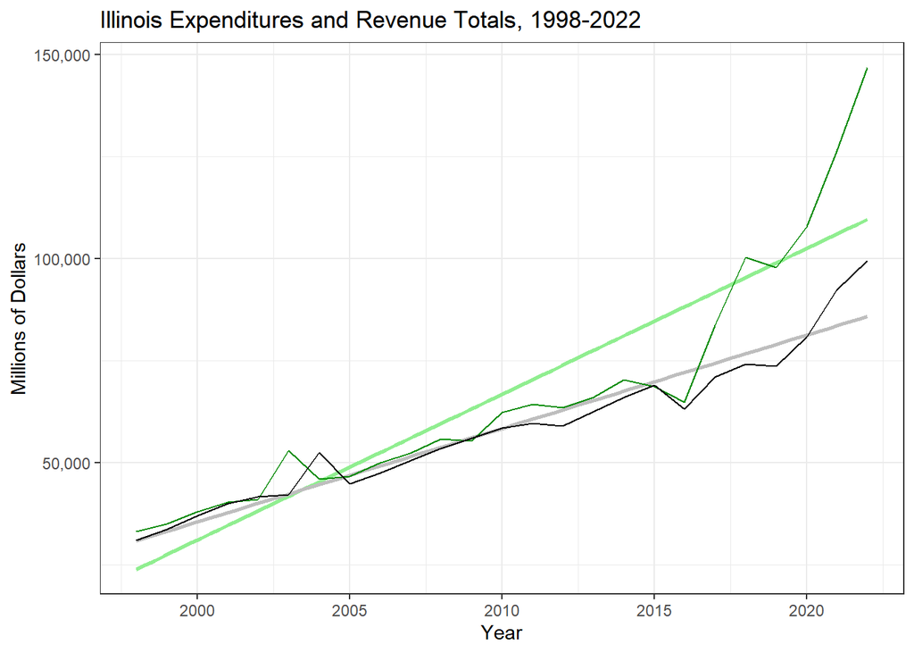

```r
year_totals %>%
  ggplot() +
  # geom_smooth adds regression line, graphed first so it appears behind line graph
  geom_smooth(aes(x = Year, y = Revenue), color = "light green", method = "lm", se = FALSE) +
  geom_smooth(aes(x = Year, y = Expenditures), color = "gray", method = "lm", se = FALSE) +

  # line graph of revenue and expenditures
  geom_line(aes(x = Year, y = Revenue), color = "green4") +
  geom_line(aes(x = Year, y = Expenditures), color = "black") +

  # labels
    theme_bw() +
  scale_y_continuous(labels = comma)+
  xlab("Year") +
  ylab("Millions of Dollars")  +
  ggtitle("Illinois Expenditures and Revenue Totals, 1998-2022")
```

**Expenditure and revenue amounts in millions of dollars:**

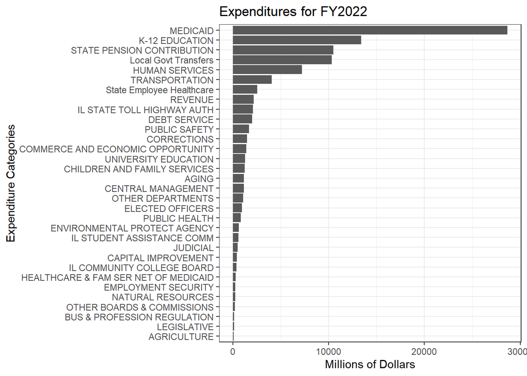

```r
exp_long %>%
  filter(Year == 2022) %>%
  #mutate(`Total Expenditures`= sum(Dollars, na.rm = TRUE)) %>%
 # select(-c(Year, `Total Expenditures`)) %>%
  arrange(desc(`Dollars`)) %>%
  ggplot() +
  geom_col(aes(x = fct_reorder(Category_name, `Dollars`), y = `Dollars`))+
  coord_flip() +
      theme_bw() +
  labs(title = "Expenditures for FY2022") +
    xlab("Expenditure Categories") +
  ylab("Millions of Dollars")
```

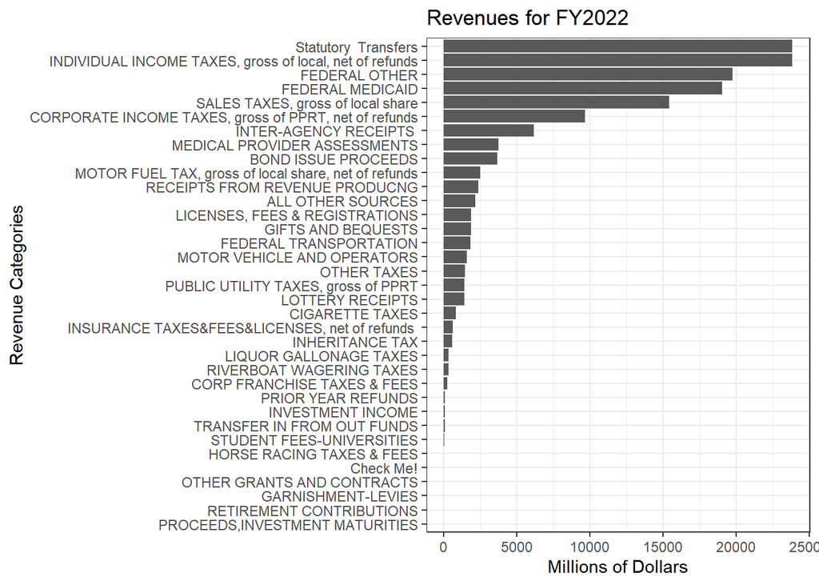

```r
rev_long %>%
  filter(Year == 2022) %>%
  #mutate(`Total Expenditures`= sum(Dollars, na.rm = TRUE)) %>%
 # select(-c(Year, `Total Expenditures`)) %>%
  arrange(desc(`Dollars`)) %>%
  ggplot() +
  geom_col(aes(x = fct_reorder(Category_name, `Dollars`), y = `Dollars`))+
  coord_flip() +
    theme_bw() +
      labs(title = "Revenues for FY2022")+
    xlab("Revenue Categories") +
  ylab("Millions of Dollars")
```

**Expenditure and revenues when focusing on largest categories and combining others into “All Other Expenditures(Revenues)”:**

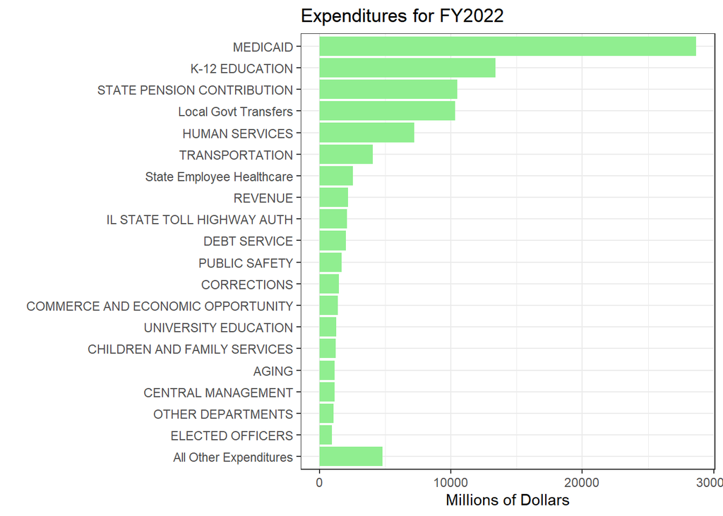

```r
exp_long %>%
  filter( Year == 2022) %>%
  mutate(rank = rank(Dollars),
        Category_name = ifelse(rank > 13, Category_name, 'All Other Expenditures')) %>%
 # select(-c(Year, Dollars, rank)) %>%
  arrange(desc(Dollars)) %>%
  ggplot() +
  geom_col(aes(x = fct_reorder(Category_name, `Dollars`), y = `Dollars`), fill = "light green")+
  coord_flip() +
      theme_bw() +
    labs(title = "Expenditures for FY2022") +
    xlab("") +
  ylab("Millions of Dollars")
```

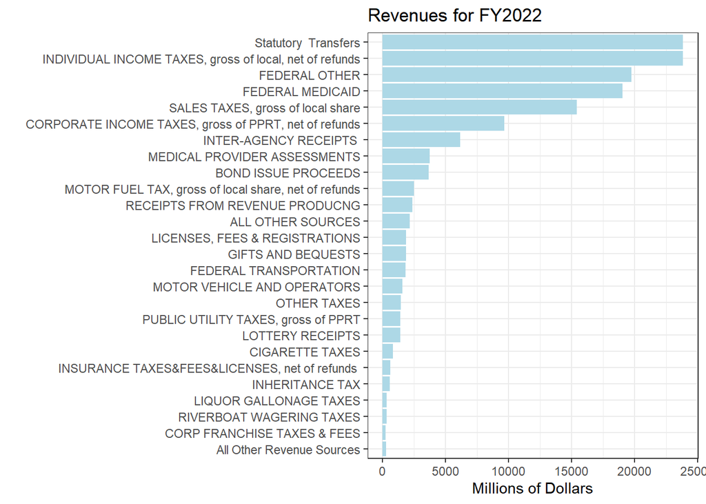

```r
rev_long %>%
  filter( Year == 2022) %>%
  mutate(rank = rank(Dollars),
        Category_name = ifelse(rank > 10, Category_name, 'All Other Revenue Sources')) %>%
  arrange(desc(Dollars)) %>%
  ggplot() +
  geom_col(aes(x = fct_reorder(Category_name, `Dollars`), y = `Dollars`), fill = "light blue")+
  coord_flip() +
      theme_bw() +
    labs(title = "Revenues for FY2022") +
    xlab("") +
  ylab("Millions of Dollars")
```

**Changes in Categories - 2021 to 2022** Dot Plot Attempt:

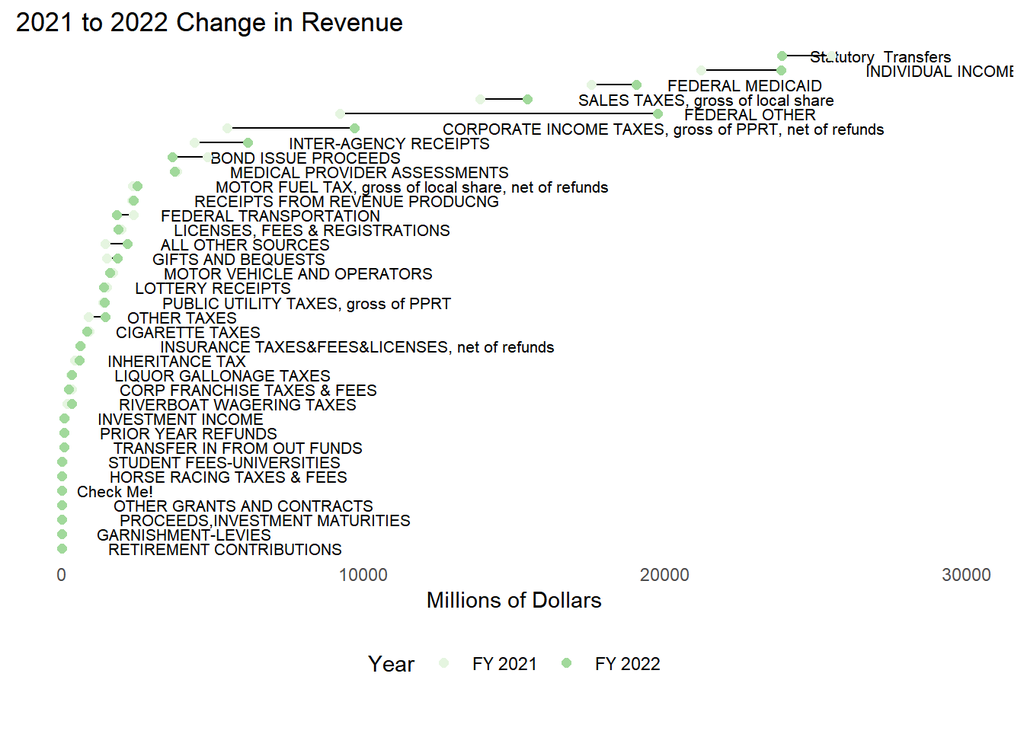

```r
rev_long %>%
    filter(Year == "2022" | Year == "2021") %>%
  mutate(Year = as.character(Year)) %>%
  ggplot(aes(x = Dollars, y = reorder(Category, Dollars))) +
  geom_line(aes(group = Category) )+
    geom_text(aes(x = ifelse(Year == "2022", as.numeric(Dollars), NA),  label = ifelse(Year == "2022", Category_name, "")),
            hjust = -0.2,
            size = 2.8) +
         geom_point(aes(color = Year), size=2)  +
  labs(title = "2021 to 2022 Change in Revenue", x = "Millions of Dollars" , y = "",  caption = "")  +
   scale_color_brewer(palette = "paired", labels = c("FY 2021", "FY 2022"))+
   theme_classic()+
    theme(
   legend.position = "bottom" ,
  axis.text.y = element_blank(),
  axis.ticks.y = element_blank(),
  axis.line.y.left  = element_blank(),
  axis.line.x = element_blank(),
    axis.title.y = element_blank(),
  axis.ticks.x = element_blank())+
  scale_x_continuous(limits = c(0, 30000))
```

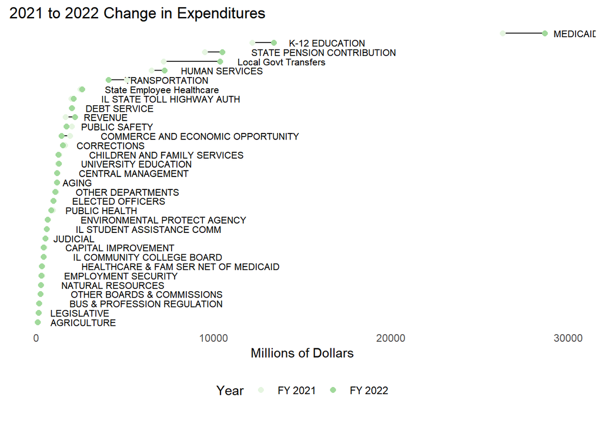

```r
exp_long %>%
    filter(Year == "2022" | Year == "2021") %>%
  mutate(Year = as.character(Year)) %>%
  ggplot(aes(x = Dollars, y = reorder(Category, Dollars))) +
  geom_line(aes(group = Category) )+
    geom_text(aes(x = ifelse(Year == "2022", as.numeric(Dollars), NA),  label = ifelse(Year == "2022", Category_name, "")),
            hjust = -0.2,
            size = 2.8) +
         geom_point(aes(color = Year), size=2)  +
  labs(title = "2021 to 2022 Change in Expenditures", x = "Millions of Dollars" , y = "",  caption = "")  +
   scale_color_brewer(palette = "paired", labels = c("FY 2021", "FY 2022"))+
   theme_classic()+
    theme(
    legend.position = "bottom" ,
  axis.text.y = element_blank(),
  axis.ticks.y = element_blank(),
  axis.line.y.left  = element_blank(),
  axis.line.x = element_blank(),
    axis.title.y = element_blank(),
  axis.ticks.x = element_blank())+
  scale_x_continuous(limits = c(0, 30000))
```